```r
if (!require('ggplot2')) install.packages('ggplot2'); library('ggplot2');
if (!require('readr')) install.packages('readr'); library('readr');
if (!require('Rmisc')) install.packages('Rmisc'); library('Rmisc');
if (!require('dplyr')) install.packages('dplyr'); library('dplyr');
# library('ggplot2')
# library('readr')
# library('Rmisc')
# library('dplyr')

if (!require('haven')) install.packages('haven'); library('haven')
brfss_2021_dataset <- read_xpt('LLCP2021.XPT')
```

## Limpieza de datos

Una vez cargado el dataset original, procedemos solo a seleccionar las columnas objetivo que fueron descritas en el documento de la practica.

```r
columns <- c("_STATE","FMONTH","DIABETE4","_RFHYPE6","TOLDHI3","_CHOLCH3", "_BMI5","_SMOKER3","_RFSMOK3","_MICHD","CVDSTRK3","_TOTINDA","_FRTLT1A","FRUITJU2","_VEGLT1A","FVGREEN1","FRENCHF1","_RFDRHV7","_HLTHPLN","MEDCOST1","CHECKUP1","GENHLTH", "PHYSHLTH","MENTHLTH","DIFFWALK","SMOKE100","PDIABTST","BLDSUGAR","DOCTDIAB","CHKHEMO3","SEXVAR","LANDSEX","_AGEG5YR", "EDUCA", "_EDUCAG","INCOME3")

diabetesData <- select(brfss_2021_dataset, columns)
summary(diabetesData$DIABETE4)
```

```
##    Min. 1st Qu.  Median    Mean 3rd Qu.    Max.    NA's
##   1.000   3.000   3.000   2.762   3.000   9.000       3
```

```r
str(diabetesData)
```

```
## tibble [438,693 × 36] (S3: tbl_df/tbl/data.frame)
##  $ _STATE  : num [1:438693] 1 1 1 1 1 1 1 1 1 1 ...
##   ..- attr(*, "label")= chr "STATE FIPS CODE"
##  $ FMONTH  : num [1:438693] 1 1 1 1 1 1 1 1 2 2 ...
##   ..- attr(*, "label")= chr "FILE MONTH"
##  $ DIABETE4: num [1:438693] 3 1 1 1 1 3 3 3 3 3 ...
##   ..- attr(*, "label")= chr "(EVER TOLD) YOU HAD DIABETES"
##  $ _RFHYPE6: num [1:438693] 1 2 2 2 1 1 2 2 1 2 ...
##   ..- attr(*, "label")= chr "HIGH BLOOD PRESSURE CALCULATED VARIABLE"
##  $ TOLDHI3 : num [1:438693] 1 1 2 1 1 2 2 1 2 2 ...
##   ..- attr(*, "label")= chr "EVER TOLD CHOLESTEROL IS HIGH"
##  $ _CHOLCH3: num [1:438693] 1 1 1 1 1 1 1 1 1 1 ...
##   ..- attr(*, "label")= chr "CHOLESTEROL CHECKED CALCULATED VARIABLE"
##  $ _BMI5   : num [1:438693] 1454 NA 2829 3347 2873 ...
##   ..- attr(*, "label")= chr "COMPUTED BODY MASS INDEX"
##  $ _SMOKER3: num [1:438693] 3 4 4 4 4 3 4 3 4 3 ...
##   ..- attr(*, "label")= chr "COMPUTED SMOKING STATUS"
##  $ _RFSMOK3: num [1:438693] 1 1 1 1 1 1 1 1 1 1 ...
##   ..- attr(*, "label")= chr "CURRENT SMOKING CALCULATED VARIABLE"
##  $ _MICHD  : num [1:438693] 2 1 1 2 1 2 2 1 2 2 ...
##   ..- attr(*, "label")= chr "RESPONDENTS THAT HAVE EVER REPORTED HAVI"
##  $ CVDSTRK3: num [1:438693] 2 2 2 2 1 2 2 2 2 2 ...
##   ..- attr(*, "label")= chr "EVER DIAGNOSED WITH A STROKE"
##  $ _TOTINDA: num [1:438693] 2 1 2 1 1 2 2 1 2 1 ...
##   ..- attr(*, "label")= chr "LEISURE TIME PHYSICAL ACTIVITY CALCULATE"
##  $ _FRTLT1A: num [1:438693] 1 1 1 1 1 2 2 2 1 1 ...
##   ..- attr(*, "label")= chr "CONSUME FRUIT 1 OR MORE TIMES PER DAY"
##  $ FRUITJU2: num [1:438693] 555 555 555 205 555 555 301 555 101 555 ...
##   ..- attr(*, "label")= chr "HOW MANY TIMES DID YOU DRINK 100 PERCENT"
##  $ _VEGLT1A: num [1:438693] 1 1 2 1 1 2 1 1 9 1 ...
##   ..- attr(*, "label")= chr "CONSUME VEGETABLES 1 OR MORE TIMES PER D"
##  $ FVGREEN1: num [1:438693] 204 201 555 303 101 201 203 202 555 202 ...
##   ..- attr(*, "label")= chr "HOW MANY TIMES DID YOU EAT DARK GREEN VE"
##  $ FRENCHF1: num [1:438693] 203 555 201 204 202 555 203 555 777 202 ...
##   ..- attr(*, "label")= chr "HOW OFTEN DO YOU EAT FRENCH FRIES OR FRI"
##  $ _RFDRHV7: num [1:438693] 1 1 1 1 1 1 1 1 1 1 ...
##   ..- attr(*, "label")= chr "HEAVY ALCOHOL CONSUMPTION  CALCULATED VA"
##  $ _HLTHPLN: num [1:438693] 1 1 1 1 1 1 1 1 1 1 ...
##   ..- attr(*, "label")= chr "HAVE ANY HEALTH INSURANCE"
##  $ MEDCOST1: num [1:438693] 2 2 2 2 2 2 2 2 2 2 ...
```

[output cut: 18 more lines]

```
##   ..- attr(*, "label")= chr "TIMES SEEN HEALTH PROFESSIONAL FOR DIABE"
##  $ CHKHEMO3: num [1:438693] NA NA NA NA NA NA NA NA NA NA ...
##   ..- attr(*, "label")= chr "TIMES CHECKED FOR GLYCOSYLATED HEMOGLOBI"
##  $ SEXVAR  : num [1:438693] 2 2 2 2 1 1 1 1 2 2 ...
##   ..- attr(*, "label")= chr "SEX OF RESPONDENT"
##  $ LANDSEX : num [1:438693] NA NA NA NA NA 1 NA 1 2 NA ...
##   ..- attr(*, "label")= chr "ARE YOU MALE OR FEMALE?"
##  $ _AGEG5YR: num [1:438693] 11 10 11 9 12 13 9 9 12 10 ...
##   ..- attr(*, "label")= chr "REPORTED AGE IN FIVE-YEAR AGE CATEGORIES"
##  $ EDUCA   : num [1:438693] 4 6 4 4 3 5 6 3 3 4 ...
##   ..- attr(*, "label")= chr "EDUCATION LEVEL"
##  $ _EDUCAG : num [1:438693] 2 4 2 2 1 3 4 1 1 2 ...
##   ..- attr(*, "label")= chr "COMPUTED LEVEL OF EDUCATION COMPLETED CA"
##  $ INCOME3 : num [1:438693] 5 77 3 7 4 6 77 99 77 8 ...
##   ..- attr(*, "label")= chr "INCOME LEVEL"
```

Eliminación de valores nulos en las columnas dependientes

```r
sort(colMeans(is.na(diabetesData)), decreasing = TRUE)
```

```
##     CHKHEMO3     DOCTDIAB     BLDSUGAR      LANDSEX     PDIABTST      TOLDHI3
## 9.493290e-01 9.493268e-01 9.493062e-01 8.863761e-01 7.387285e-01 1.386756e-01
##        _BMI5     FRENCHF1     FVGREEN1     FRUITJU2     SMOKE100     DIFFWALK
## 1.067991e-01 8.687396e-02 8.433004e-02 8.151942e-02 4.839831e-02 4.105149e-02
##      INCOME3       _MICHD     MEDCOST1        EDUCA      GENHLTH     DIABETE4
## 2.016672e-02 1.056548e-02 1.139749e-05 1.139749e-05 9.117994e-06 6.838495e-06
##     PHYSHLTH     CVDSTRK3     CHECKUP1     MENTHLTH       _STATE       FMONTH
## 6.838495e-06 4.558997e-06 4.558997e-06 4.558997e-06 0.000000e+00 0.000000e+00
##     _RFHYPE6     _CHOLCH3     _SMOKER3     _RFSMOK3     _TOTINDA     _FRTLT1A
## 0.000000e+00 0.000000e+00 0.000000e+00 0.000000e+00 0.000000e+00 0.000000e+00
##     _VEGLT1A     _RFDRHV7     _HLTHPLN       SEXVAR     _AGEG5YR      _EDUCAG
## 0.000000e+00 0.000000e+00 0.000000e+00 0.000000e+00 0.000000e+00 0.000000e+00
```

Columnas que tengan al menos 2% de valores vacíos

```r
columns_to_remove <- which(colMeans(is.na(diabetesData)) > 0.02)
columns_to_remove
```

```
##  TOLDHI3    _BMI5 FRUITJU2 FVGREEN1 FRENCHF1 DIFFWALK SMOKE100 PDIABTST
##        5        7       14       16       17       25       26       27
## BLDSUGAR DOCTDIAB CHKHEMO3  LANDSEX  INCOME3
##       28       29       30       32       36
```

Para este caso, podemos observar que existen varias columnas que cuentan con un porcentaje mayor al 2% de valores nulos, gran parte de esas columnas son características propias de una persona diabética y que este universo de personas dio respuesta en la encuesta, es por ello que decidimos no eliminar ninguna columna, ya que más adelante analizaremos solo a las personas diabéticas independientemente de las características “vacías”.

A continuación, realizaremos una selección, reemplazo y eliminación en la columna DIABETE4, ya que para este estudio solo nos interesara saber si una persona respondió si es diabética o no, según los siguientes criterios:

Antes de continuar, dentro de las respuestas puede darse el caso que se encuentren respuestas vacias o que diractamente se rechazo a responder, para estos casos, estas respuestas seran eliminadas directamente del dataset, ya que no aporta valor al analisis.

```
# Let's make this ordinal. 0 is for no diabetes or only during pregnancy, 1 is for prediabetes or borderline diabetes, 2 is for yes diabetes.
# remove all 7 (dont knows)
# remove all 9 (refused)
```

```r
diabetesData$DIABETE4[diabetesData$DIABETE4 %in% c(2,3)]<- 0
diabetesData$DIABETE4[diabetesData$DIABETE4 ==4 ]<- 1
diabetesData$DIABETE4[diabetesData$DIABETE4 ==1 ]<- 2

diabetesData = subset(diabetesData, !(DIABETE4 %in% c(7,9)))
diabetesData = subset(diabetesData, !is.na(DIABETE4))
summary(diabetesData$DIABETE4)
```

```
##    Min. 1st Qu.  Median    Mean 3rd Qu.    Max.
##  0.0000  0.0000  0.0000  0.3087  0.0000  2.0000
```

```
#_RFHYPE6
# Cambiar 1 a 0 para que represente No hipertensión y 2 a 1 para que represente Hipertensión.
```

```r
diabetesData["_RFHYPE6"][diabetesData["_RFHYPE6"] ==1 ]<- 0
diabetesData["_RFHYPE6"][diabetesData["_RFHYPE6"] ==2 ]<- 1

diabetesData = subset(diabetesData, diabetesData["_RFHYPE6"] !=9)
diabetesData = subset(diabetesData, !is.na("_RFHYPE6"))

summary(diabetesData["_RFHYPE6"])
```

```
##     _RFHYPE6
##  Min.   :0.000
##  1st Qu.:0.000
##  Median :0.000
##  Mean   :0.394
##  3rd Qu.:1.000
##  Max.   :1.000
```

```
#TOLDHI3
# Change 2 to 0 because it is No
# Remove all 7 (dont knows)
# Remove all 9 (refused)
```

```r
sum(is.na(diabetesData$TOLDHI3))
```

```
## [1] 59991
```

Antes de empezar con la limpieza de la columna, podemos identificar que existen 59991 registros que deben ser removidos del dataset a estudiar, ya que pertenecen a preguntas no respondidas en la encuesta, de preferencia es necesario no tomar en cuenta estos registros, ya que pueden afectar al resultado final del análisis.

```r
#diabetesData$TOLDHI3
diabetesData$TOLDHI3[diabetesData$TOLDHI3 ==2 ]<- 0

diabetesData = subset(diabetesData, !TOLDHI3 %in% c(7,9))
diabetesData = subset(diabetesData, !is.na(TOLDHI3))
summary(diabetesData$TOLDHI3)
```

```
##    Min. 1st Qu.  Median    Mean 3rd Qu.    Max.
##  0.0000  0.0000  0.0000  0.3995  1.0000  1.0000
```

[output not shown]

```r
sum(is.na(diabetesData["_CHOLCH3"]))
```

```
## [1] 0
```

```r
diabetesData = subset(diabetesData, !is.na(diabetesData["_BMI5"]))
diabetesData["_CHOLCH3"][diabetesData["_CHOLCH3"] == 3 ]<- 0
diabetesData = subset(diabetesData, diabetesData["_CHOLCH3"] !=9)

summary(diabetesData["_CHOLCH3"])
```

```
##     _CHOLCH3
##  Min.   :1.000
##  1st Qu.:1.000
##  Median :1.000
##  Mean   :1.036
##  3rd Qu.:1.000
##  Max.   :2.000
```

```
#_BMI5 (no changes, just note that these are BMI * 100. So for example a BMI of 4018 is really 40.18)
```

```r
sum(is.na(diabetesData["_BMI5"]))
```

```
## [1] 0
```

```r
diabetesData = subset(diabetesData, !is.na(diabetesData["_BMI5"]))
diabetesData["_BMI5"]<- round(diabetesData["_BMI5"]/100, 0)

summary(diabetesData["_BMI5"])
```

```
##      _BMI5
##  Min.   :12.00
##  1st Qu.:24.00
##  Median :28.00
##  Mean   :28.77
##  3rd Qu.:32.00
##  Max.   :99.00
```

```
#SMOKE100
# Change 2 to 0 because it is No
# Remove all 7 (dont knows)
# Remove all 9 (refused)
```

```r
sum(is.na(diabetesData$SMOKE100))
```

```
## [1] 5380
```

```r
diabetesData = subset(diabetesData, !is.na(SMOKE100))

diabetesData$SMOKE100[diabetesData$SMOKE100 ==2 ]<- 0
diabetesData = subset(diabetesData, !SMOKE100 %in% c(7,9))
summary(diabetesData$SMOKE100)
```

```
##    Min. 1st Qu.  Median    Mean 3rd Qu.    Max.
##  0.0000  0.0000  0.0000  0.4138  1.0000  1.0000
```

```
#CVDSTRK3
# Change 2 to 0 because it is No
# Remove all 7 (dont knows)
# Remove all 9 (refused)
```

```r
sum(is.na(diabetesData$CVDSTRK3))
```

```
## [1] 0
```

```r
diabetesData$CVDSTRK3[diabetesData$CVDSTRK3 ==2 ]<- 0
diabetesData = subset(diabetesData, !CVDSTRK3 %in% c(7,9))
summary(diabetesData$CVDSTRK3)
```

```
##    Min. 1st Qu.  Median    Mean 3rd Qu.    Max.
## 0.00000 0.00000 0.00000 0.04285 0.00000 1.00000
```

```
#_MICHD
#Change 2 to 0 because this means did not have MI or CHD
```

```r
sum(is.na(diabetesData["_MICHD"]))
```

```
## [1] 2781
```

```r
diabetesData = subset(diabetesData, !is.na(diabetesData["_MICHD"]))
diabetesData['_MICHD'][diabetesData["_MICHD"] ==2 ]<- 0
summary(diabetesData["_MICHD"])
```

```
##      _MICHD
##  Min.   :0.00000
##  1st Qu.:0.00000
##  Median :0.00000
##  Mean   :0.09119
##  3rd Qu.:0.00000
##  Max.   :1.00000
```

```
#_TOTINDA
# 1 for physical activity
# change 2 to 0 for no physical activity
# Remove all 9 (don't know/refused)
```

```r
sum(is.na(diabetesData["_TOTINDA"]))
```

```
## [1] 0
```

```r
diabetesData = subset(diabetesData, !is.na(diabetesData["_TOTINDA"]))
diabetesData = subset(diabetesData, diabetesData["_TOTINDA"] !=9)
diabetesData['_TOTINDA'][diabetesData["_TOTINDA"] ==2 ]<- 0
summary(diabetesData["_TOTINDA"])
```

```
##     _TOTINDA
##  Min.   :0.000
##  1st Qu.:1.000
##  Median :1.000
##  Mean   :0.765
##  3rd Qu.:1.000
##  Max.   :1.000
```

```
#_FRTLT1A
# Change 2 to 0. this means no fruit consumed per day. 1 will mean consumed 1 or more pieces of fruit per day
# remove all dont knows and missing 9
```

```r
sum(is.na(diabetesData["_FRTLT1A"]))
```

```
## [1] 0
```

```r
diabetesData = subset(diabetesData, diabetesData["_FRTLT1A"] !=9)
diabetesData['_FRTLT1A'][diabetesData["_FRTLT1A"] == 2 ]<- 0
summary(diabetesData["_FRTLT1A"])
```

```
##     _FRTLT1A
##  Min.   :0.0000
##  1st Qu.:0.0000
##  Median :1.0000
##  Mean   :0.6246
##  3rd Qu.:1.0000
##  Max.   :1.0000
```

```
#_VEGLT1A
# Change 2 to 0. this means no vegetables consumed per day. 1 will mean consumed 1 or more pieces of vegetable per day
# remove all dont knows and missing 9
```

```r
sum(is.na(diabetesData["_VEGLT1A"]))
```

```
## [1] 0
```

```r
diabetesData = subset(diabetesData, diabetesData["_VEGLT1A"] !=9)
diabetesData['_VEGLT1A'][diabetesData["_VEGLT1A"] == 2 ]<- 0
summary(diabetesData["_VEGLT1A"])
```

```
##     _VEGLT1A
##  Min.   :0.0000
##  1st Qu.:1.0000
##  Median :1.0000
##  Mean   :0.8241
##  3rd Qu.:1.0000
##  Max.   :1.0000
```

```
#_HLTHPLN
# 1 is yes, change 2 to 0 because it is No health care access
# remove 7 and 9 for don't know or refused
```

```r
sum(is.na(diabetesData["_HLTHPLN"]))
```

```
## [1] 0
```

```r
diabetesData = subset(diabetesData, diabetesData["_HLTHPLN"] !=9)
diabetesData['_HLTHPLN'][diabetesData["_HLTHPLN"] == 2 ]<- 0
summary(diabetesData["_HLTHPLN"])
```

```
##     _HLTHPLN
##  Min.   :0.0000
##  1st Qu.:1.0000
##  Median :1.0000
##  Mean   :0.9617
##  3rd Qu.:1.0000
##  Max.   :1.0000
```

```
#MEDCOST1
# Change 2 to 0 for no, 1 is already yes
# remove 7 for don/t know and 9 for refused
```

```r
sum(is.na(diabetesData["MEDCOST1"]))
```

```
## [1] 1
```

```r
diabetesData = subset(diabetesData, !is.na(MEDCOST1))
diabetesData = subset(diabetesData, diabetesData["MEDCOST1"] !=7)
diabetesData = subset(diabetesData, diabetesData["MEDCOST1"] !=9)
diabetesData['MEDCOST1'][diabetesData["MEDCOST1"] == 2 ]<- 0
summary(diabetesData["MEDCOST1"])
```

```
##     MEDCOST1
##  Min.   :0.00000
##  1st Qu.:0.00000
##  Median :0.00000
##  Mean   :0.06345
##  3rd Qu.:0.00000
##  Max.   :1.00000
```

```
#GENHLTH
# This is an ordinal variable that I want to keep (1 is Excellent -> 5 is Poor)
# Remove 7 and 9 for don't know and refused
```

```r
sum(is.na(diabetesData["GENHLTH"]))
```

```
## [1] 2
```

```r
diabetesData = subset(diabetesData, !is.na(GENHLTH))
diabetesData = subset(diabetesData, diabetesData["GENHLTH"] !=7)
diabetesData = subset(diabetesData, diabetesData["GENHLTH"] !=9)
summary(diabetesData["GENHLTH"])
```

```
##     GENHLTH
##  Min.   :1.000
##  1st Qu.:2.000
##  Median :2.000
##  Mean   :2.499
##  3rd Qu.:3.000
##  Max.   :5.000
```

```
#MENTHLTH
# already in days so keep that, scale will be 0-30
# change 88 to 0 because it means none (no bad mental health days)
# remove 77 and 99 for don't know not sure and refused
```

```r
sum(is.na(diabetesData["MENTHLTH"]))
```

```
## [1] 0
```

```r
diabetesData = subset(diabetesData, diabetesData["MENTHLTH"] !=77)
diabetesData = subset(diabetesData, diabetesData["MENTHLTH"] !=99)
diabetesData['MENTHLTH'][diabetesData["MENTHLTH"] == 88 ]<- 0
summary(diabetesData["MENTHLTH"])
```

```
##     MENTHLTH
##  Min.   : 0.000
##  1st Qu.: 0.000
##  Median : 0.000
##  Mean   : 3.887
##  3rd Qu.: 3.000
##  Max.   :30.000
```

```
#PHYSHLTH
# already in days so keep that, scale will be 0-30
# change 88 to 0 because it means none (no bad mental health days)
# remove 77 and 99 for don't know not sure and refused
```

```r
sum(is.na(diabetesData["PHYSHLTH"]))
```

```
## [1] 2
```

```r
diabetesData = subset(diabetesData, !is.na(PHYSHLTH))
diabetesData = subset(diabetesData, diabetesData["PHYSHLTH"] !=77)
diabetesData = subset(diabetesData, diabetesData["PHYSHLTH"] !=99)
diabetesData['PHYSHLTH'][diabetesData["PHYSHLTH"] == 88 ]<- 0
summary(diabetesData["PHYSHLTH"])
```

```
##     PHYSHLTH
##  Min.   : 0.000
##  1st Qu.: 0.000
##  Median : 0.000
##  Mean   : 3.771
##  3rd Qu.: 2.000
##  Max.   :30.000
```

```
#DIFFWALK
# change 2 to 0 for no. 1 is already yes
# remove 7 and 9 for don't know not sure and refused
```

```r
sum(is.na(diabetesData["DIFFWALK"]))
```

```
## [1] 0
```

```r
diabetesData = subset(diabetesData, diabetesData["DIFFWALK"] !=7)
diabetesData = subset(diabetesData, diabetesData["DIFFWALK"] !=9)
diabetesData['DIFFWALK'][diabetesData["DIFFWALK"] == 2 ]<- 0
summary(diabetesData["DIFFWALK"])
```

```
##     DIFFWALK
##  Min.   :0.0000
##  1st Qu.:0.0000
##  Median :0.0000
##  Mean   :0.1565
##  3rd Qu.:0.0000
##  Max.   :1.0000
```

```
#SEXVAR
# in other words - is respondent male (somewhat arbitrarily chose this change because men are at higher risk for heart disease)
# change 2 to 0 (female as 0). Male is 1
```

```r
sum(is.na(diabetesData["SEXVAR"]))
```

```
## [1] 0
```

```r
diabetesData['SEXVAR'][diabetesData["SEXVAR"] == 2 ]<- 0
summary(diabetesData["SEXVAR"])
```

```
##      SEXVAR
##  Min.   :0.0000
##  1st Qu.:0.0000
##  Median :0.0000
##  Mean   :0.4704
##  3rd Qu.:1.0000
##  Max.   :1.0000
```

```
#_AGEG5YR
# already ordinal. 1 is 18-24 all the way up to 13 wis 80 and older. 5 year increments.
# remove 14 because it is don't know or missing
```

```r
sum(is.na(diabetesData["_AGEG5YR"]))
```

```
## [1] 0
```

```r
diabetesData = subset(diabetesData, diabetesData["_AGEG5YR"] !=14)
summary(diabetesData["_AGEG5YR"])
```

```
##     _AGEG5YR
##  Min.   : 1.000
##  1st Qu.: 6.000
##  Median : 8.000
##  Mean   : 7.981
##  3rd Qu.:11.000
##  Max.   :13.000
```

[output not shown]

```r
sum(is.na(diabetesData["_EDUCAG"]))
```

```
## [1] 0
```

```r
diabetesData = subset(diabetesData, diabetesData["_EDUCAG"] !=9)
summary(diabetesData["_EDUCAG"])
```

```
##     _EDUCAG
##  Min.   :1.000
##  1st Qu.:2.000
##  Median :3.000
##  Mean   :3.134
##  3rd Qu.:4.000
##  Max.   :4.000
```

[output not shown]

```r
sum(is.na(diabetesData["INCOME3"]))
```

```
## [1] 5
```

```r
diabetesData = subset(diabetesData, diabetesData["INCOME3"] !=77)
diabetesData = subset(diabetesData, diabetesData["INCOME3"] !=99)

summary(diabetesData["INCOME3"])
```

```
##     INCOME3
##  Min.   : 1.000
##  1st Qu.: 5.000
##  Median : 7.000
##  Mean   : 6.923
##  3rd Qu.: 9.000
##  Max.   :11.000
```

```
#BIMG
#Replace <18.5 - 0 debajo normal
#Replace 18.5 > x <= 25  - 1 normal
#Replace  25 > x <=30 - 2 sobrepeso
#Replace >30 - 3 obesidad
```

```r
diabetesData['BMIG'] = 1
#sum(is.na(diabetesData["_BMI5"]))
diabetesData["BMIG"][diabetesData["_BMI5"] <= 18.5] <- 0
diabetesData["BMIG"][diabetesData["_BMI5"] > 18.5 & diabetesData["_BMI5"] <=25] <- 1
diabetesData["BMIG"][diabetesData["_BMI5"] > 25 & diabetesData["_BMI5"] <=30] <- 2
diabetesData["BMIG"][diabetesData["_BMI5"] > 30] <- 3

summary(diabetesData["BMIG"])
```

```
##       BMIG
##  Min.   :0.000
##  1st Qu.:1.000
##  Median :2.000
##  Mean   :2.002
##  3rd Qu.:3.000
##  Max.   :3.000
```

[output not shown]

```r
dim(diabetesData)
```

```
## [1] 238611     37
```

```
#Check Class Sizes of the heart disease column
```

```r
# diabetesData$DIABETE4
summary(diabetesData$DIABETE4)
```

```
##    Min. 1st Qu.  Median    Mean 3rd Qu.    Max.
##  0.0000  0.0000  0.0000  0.3309  0.0000  2.0000
```

## Análisis exploratorio de los datos

Para una mejor comprensión de las columnas, a continuación realizaremos un proceso de renombre de las mismas.

```r
library("dplyr")

newDiabetesData <- diabetesData %>%
        dplyr::rename("Diabetes_012" = "DIABETE4",
                      "HighBP"="_RFHYPE6",
                      "HighChol"="TOLDHI3",
                      "CholCheck"="_CHOLCH3",
                      "BMI" = "_BMI5",
                      "Smoker" = "SMOKE100",
                      "Stroke" = "CVDSTRK3",
                      "HeartDiseaseorAttack" = "_MICHD",
                      "PhysActivity" = "_TOTINDA",
                      "Fruits" = "_FRTLT1A",
                      "Veggies" = "_VEGLT1A",
                      "HvyAlcoholConsump" = "_RFDRHV7",
                      "AnyHealthcare" = "_HLTHPLN",
                      "NoDocbcCost" = "MEDCOST1",
                      "GenHlth" = "GENHLTH",
                      "MentHlth"  = "MENTHLTH",
                      "PhysHlth" = "PHYSHLTH",
                      "DiffWalk" = "DIFFWALK",
                      "Sex" = "SEXVAR",
                      "Age" = "_AGEG5YR",
                      "Education" = "EDUCA",
                      "Income" = "INCOME3",
                      "State" = "_STATE"
                      )
```

```r
summary(newDiabetesData)
```

```
##      State           FMONTH        Diabetes_012        HighBP
##  Min.   : 1.00   Min.   : 1.000   Min.   :0.0000   Min.   :0.0000
##  1st Qu.:20.00   1st Qu.: 4.000   1st Qu.:0.0000   1st Qu.:0.0000
##  Median :31.00   Median : 6.000   Median :0.0000   Median :0.0000
##  Mean   :30.85   Mean   : 6.401   Mean   :0.3309   Mean   :0.4187
##  3rd Qu.:42.00   3rd Qu.: 9.000   3rd Qu.:0.0000   3rd Qu.:1.0000
##  Max.   :78.00   Max.   :12.000   Max.   :2.0000   Max.   :1.0000
##
##     HighChol        CholCheck          BMI           _SMOKER3
##  Min.   :0.0000   Min.   :1.000   Min.   :12.00   Min.   :1.000
##  1st Qu.:0.0000   1st Qu.:1.000   1st Qu.:24.00   1st Qu.:3.000
##  Median :0.0000   Median :1.000   Median :28.00   Median :4.000
##  Mean   :0.4019   Mean   :1.037   Mean   :28.95   Mean   :3.376
##  3rd Qu.:1.0000   3rd Qu.:1.000   3rd Qu.:32.00   3rd Qu.:4.000
##  Max.   :1.0000   Max.   :2.000   Max.   :99.00   Max.   :9.000
##
##     _RFSMOK3     HeartDiseaseorAttack     Stroke         PhysActivity
##  Min.   :1.000   Min.   :0.00000      Min.   :0.00000   Min.   :0.000
##  1st Qu.:1.000   1st Qu.:0.00000      1st Qu.:0.00000   1st Qu.:1.000
##  Median :1.000   Median :0.00000      Median :0.00000   Median :1.000
##  Mean   :1.126   Mean   :0.08645      Mean   :0.03891   Mean   :0.779
##  3rd Qu.:1.000   3rd Qu.:0.00000      3rd Qu.:0.00000   3rd Qu.:1.000
##  Max.   :9.000   Max.   :1.00000      Max.   :1.00000   Max.   :1.000
##
##      Fruits          FRUITJU2      Veggies          FVGREEN1
##  Min.   :0.0000   Min.   :101   Min.   :0.0000   Min.   :101.0
##  1st Qu.:0.0000   1st Qu.:202   1st Qu.:1.0000   1st Qu.:201.0
##  Median :1.0000   Median :304   Median :1.0000   Median :203.0
##  Mean   :0.6211   Mean   :364   Mean   :0.8276   Mean   :227.6
##  3rd Qu.:1.0000   3rd Qu.:555   3rd Qu.:1.0000   3rd Qu.:302.0
##  Max.   :1.0000   Max.   :555   Max.   :1.0000   Max.   :555.0
##
##     FRENCHF1     HvyAlcoholConsump AnyHealthcare     NoDocbcCost
##  Min.   :101.0   Min.   :1.000     Min.   :0.0000   Min.   :0.000
##  1st Qu.:202.0   1st Qu.:1.000     1st Qu.:1.0000   1st Qu.:0.000
##  Median :301.0   Median :1.000     Median :1.0000   Median :0.000
##  Mean   :292.2   Mean   :1.136     Mean   :0.9623   Mean   :0.064
##  3rd Qu.:304.0   3rd Qu.:1.000     3rd Qu.:1.0000   3rd Qu.:0.000
##  Max.   :555.0   Max.   :9.000     Max.   :1.0000   Max.   :1.000
##
```

[output cut: 25 more lines]

```
##  Min.   : 1.000   Min.   :1.000   Min.   :1.00   Min.   : 1.000
##  1st Qu.: 5.000   1st Qu.:4.000   1st Qu.:2.00   1st Qu.: 5.000
##  Median : 8.000   Median :5.000   Median :3.00   Median : 7.000
##  Mean   : 7.861   Mean   :5.137   Mean   :3.15   Mean   : 6.923
##  3rd Qu.:10.000   3rd Qu.:6.000   3rd Qu.:4.00   3rd Qu.: 9.000
##  Max.   :13.000   Max.   :6.000   Max.   :4.00   Max.   :11.000
##
##       BMIG
##  Min.   :0.000
##  1st Qu.:1.000
##  Median :2.000
##  Mean   :2.002
##  3rd Qu.:3.000
##  Max.   :3.000
##
```

```r
write.csv2(newDiabetesData, "Practica2.csv", row.names=TRUE)
```

Para este caso, nos interesa separar en 2 clases la variable objetivo, 0 para no diabetes o diabetes en el embarazo y 1 para prediabetes y diabetes, para ello crearemos un dataset a partir del dataset principal, pero antes miraremos si existen valores nulos que puedan afectar el análisis.

```r
sort(colMeans(is.na(newDiabetesData)), decreasing = TRUE)
```

```
##             CHKHEMO3             DOCTDIAB             BLDSUGAR
##            0.9449564            0.9449522            0.9449355
##              LANDSEX             PDIABTST                State
##            0.8934291            0.7396222            0.0000000
##               FMONTH         Diabetes_012               HighBP
##            0.0000000            0.0000000            0.0000000
##             HighChol            CholCheck                  BMI
##            0.0000000            0.0000000            0.0000000
##             _SMOKER3             _RFSMOK3 HeartDiseaseorAttack
##            0.0000000            0.0000000            0.0000000
##               Stroke         PhysActivity               Fruits
##            0.0000000            0.0000000            0.0000000
##             FRUITJU2              Veggies             FVGREEN1
##            0.0000000            0.0000000            0.0000000
##             FRENCHF1    HvyAlcoholConsump        AnyHealthcare
##            0.0000000            0.0000000            0.0000000
##          NoDocbcCost             CHECKUP1              GenHlth
##            0.0000000            0.0000000            0.0000000
##             PhysHlth             MentHlth             DiffWalk
##            0.0000000            0.0000000            0.0000000
##               Smoker                  Sex                  Age
##            0.0000000            0.0000000            0.0000000
##            Education              _EDUCAG               Income
##            0.0000000            0.0000000            0.0000000
##                 BMIG
##            0.0000000
```

Para este caso, todas las personas diabéticas las agregamos en la clase pre diabético/diabético (1), y las personas sin diabetes y/o diabetes durante el embarazo en la clase 0.

```r
newDiabetesData$Diabetes_012[newDiabetesData$Diabetes_012 == 2] <- 1
```

A continuación graficaremos el número de personas con/sin diabetes en este estudio, así podremos ver a breves rasgos el resultado de la encuesta.

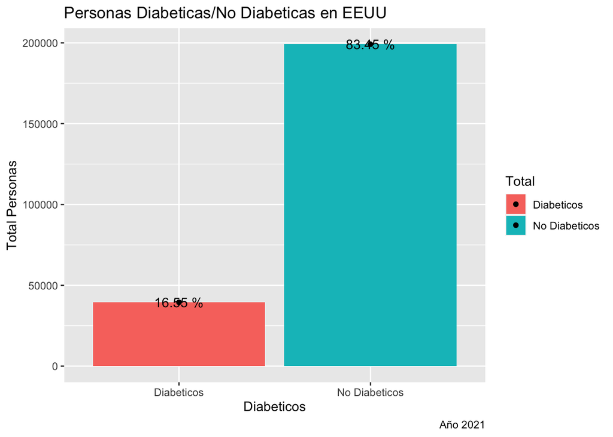

```r
    newDiabetesData%>% group_by(Diabetes_012) %>%
    dplyr::summarise(total = n()) %>%
    ggplot(aes(x = c("No Diabeticos", "Diabeticos"), y=total, fill=c("No Diabeticos", "Diabeticos")))+
    geom_col(stat = "identity") +
    guides(fill = guide_legend(title = "Total"), color=guide_legend(title="Genero"))+
    geom_text(aes(label=paste(round((total/sum(total)*100),2),"%"))) +
    geom_point(bins = 30) +
    labs(title='Personas Diabeticas/No Diabeticas en EEUU',
             x='Diabeticos',
             y='Total Personas',
             colour = "Cylinders",
             caption = "Año 2021")
```

Ahora bien, observamos que, dentro del conjunto de datos, gran porcentaje de la muestra son personas que no padecen diabetes o la padecieron durante el embarazo.

```r
diabeticos <- newDiabetesData %>% filter(Diabetes_012 == 1)

summary(diabeticos)
```

```
##      State           FMONTH        Diabetes_012     HighBP
##  Min.   : 1.00   Min.   : 1.000   Min.   :1     Min.   :0.0000
##  1st Qu.:20.00   1st Qu.: 4.000   1st Qu.:1     1st Qu.:0.0000
##  Median :31.00   Median : 6.000   Median :1     Median :1.0000
##  Mean   :31.22   Mean   : 6.434   Mean   :1     Mean   :0.7128
##  3rd Qu.:42.00   3rd Qu.: 9.000   3rd Qu.:1     3rd Qu.:1.0000
##  Max.   :78.00   Max.   :12.000   Max.   :1     Max.   :1.0000
##
##     HighChol        CholCheck          BMI           _SMOKER3
##  Min.   :0.0000   Min.   :1.000   Min.   :12.00   Min.   :1.000
##  1st Qu.:0.0000   1st Qu.:1.000   1st Qu.:27.00   1st Qu.:3.000
##  Median :1.0000   Median :1.000   Median :31.00   Median :4.000
##  Mean   :0.6311   Mean   :1.006   Mean   :32.08   Mean   :3.299
##  3rd Qu.:1.0000   3rd Qu.:1.000   3rd Qu.:36.00   3rd Qu.:4.000
##  Max.   :1.0000   Max.   :2.000   Max.   :99.00   Max.   :9.000
##
##     _RFSMOK3     HeartDiseaseorAttack     Stroke         PhysActivity
##  Min.   :1.000   Min.   :0.0000       Min.   :0.00000   Min.   :0.000
##  1st Qu.:1.000   1st Qu.:0.0000       1st Qu.:0.00000   1st Qu.:0.000
##  Median :1.000   Median :0.0000       Median :0.00000   Median :1.000
##  Mean   :1.132   Mean   :0.1946       Mean   :0.08222   Mean   :0.641
##  3rd Qu.:1.000   3rd Qu.:0.0000       3rd Qu.:0.00000   3rd Qu.:1.000
##  Max.   :9.000   Max.   :1.0000       Max.   :1.00000   Max.   :1.000
##
##      Fruits          FRUITJU2        Veggies          FVGREEN1
##  Min.   :0.0000   Min.   :101.0   Min.   :0.0000   Min.   :101.0
##  1st Qu.:0.0000   1st Qu.:203.0   1st Qu.:1.0000   1st Qu.:201.0
##  Median :1.0000   Median :314.0   Median :1.0000   Median :203.0
##  Mean   :0.5875   Mean   :381.2   Mean   :0.7873   Mean   :235.8
##  3rd Qu.:1.0000   3rd Qu.:555.0   3rd Qu.:1.0000   3rd Qu.:302.0
##  Max.   :1.0000   Max.   :555.0   Max.   :1.0000   Max.   :555.0
##
##     FRENCHF1     HvyAlcoholConsump AnyHealthcare     NoDocbcCost
##  Min.   :101.0   Min.   :1.00      Min.   :0.0000   Min.   :0.00000
##  1st Qu.:202.0   1st Qu.:1.00      1st Qu.:1.0000   1st Qu.:0.00000
##  Median :301.0   Median :1.00      Median :1.0000   Median :0.00000
##  Mean   :296.2   Mean   :1.09      Mean   :0.9726   Mean   :0.07421
##  3rd Qu.:305.0   3rd Qu.:1.00      3rd Qu.:1.0000   3rd Qu.:0.00000
##  Max.   :555.0   Max.   :9.00      Max.   :1.0000   Max.   :1.00000
##
```

[output cut: 25 more lines]

```
##  Min.   : 1.000   Min.   :1.000   Min.   :1.00   Min.   : 1.000
##  1st Qu.: 8.000   1st Qu.:4.000   1st Qu.:2.00   1st Qu.: 5.000
##  Median :10.000   Median :5.000   Median :3.00   Median : 6.000
##  Mean   : 9.294   Mean   :4.905   Mean   :2.93   Mean   : 6.065
##  3rd Qu.:11.000   3rd Qu.:6.000   3rd Qu.:4.00   3rd Qu.: 8.000
##  Max.   :13.000   Max.   :6.000   Max.   :4.00   Max.   :11.000
##
##       BMIG
##  Min.   :0.000
##  1st Qu.:2.000
##  Median :3.000
##  Mean   :2.362
##  3rd Qu.:3.000
##  Max.   :3.000
##
```

```r
diabeticofumadores <- diabeticos %>% group_by(Smoker) %>%
  dplyr::summarize(total = n())
  diabeticofumadores
```

```
## # A tibble: 2 × 2
##   Smoker total
##    <dbl> <int>
## 1      0 20661
## 2      1 18819
```

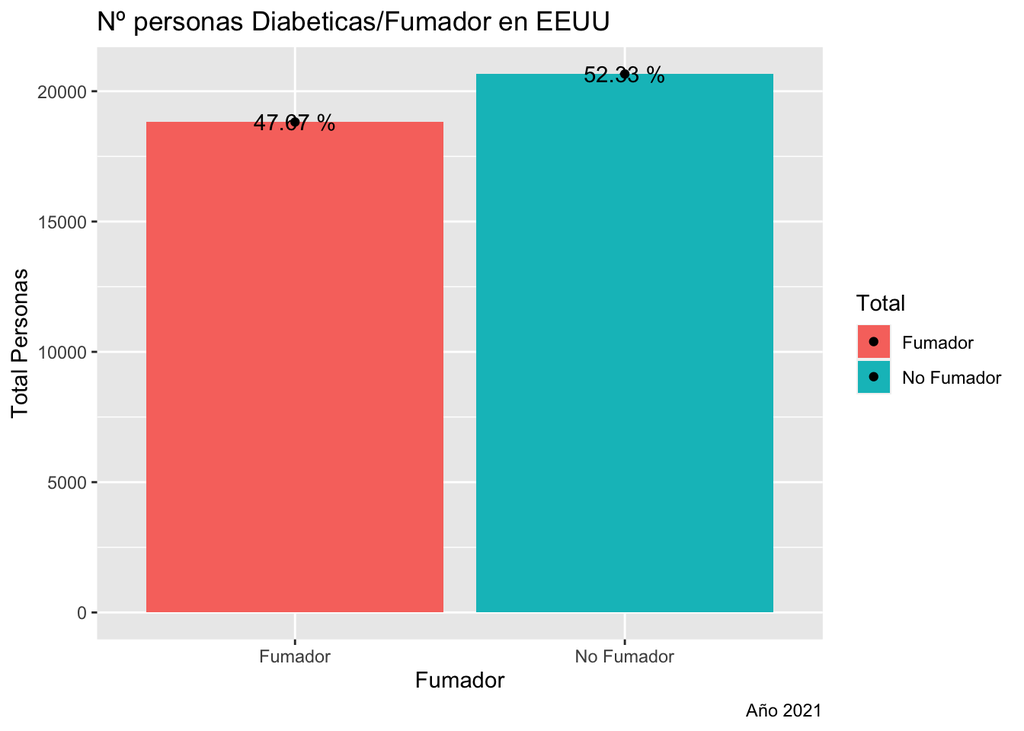

```r
  diabeticofumadores%>%
   ggplot(aes(x = c("No Fumador", "Fumador"), y=total, fill=c("No Fumador", "Fumador"))) +
    geom_col(stat = "identity") +
    guides(fill = guide_legend(title = "Total"), color=guide_legend(title="Genero"))+
    geom_text(aes(label=paste(round((total/sum(total)*100),2),"%"))) +
    geom_point(bins = 30) +
    labs(title='Nº personas Diabeticas/Fumador en EEUU',
             x='Fumador',
             y='Total Personas',
             colour = "Cylinders",
             caption = "Año 2021")
```

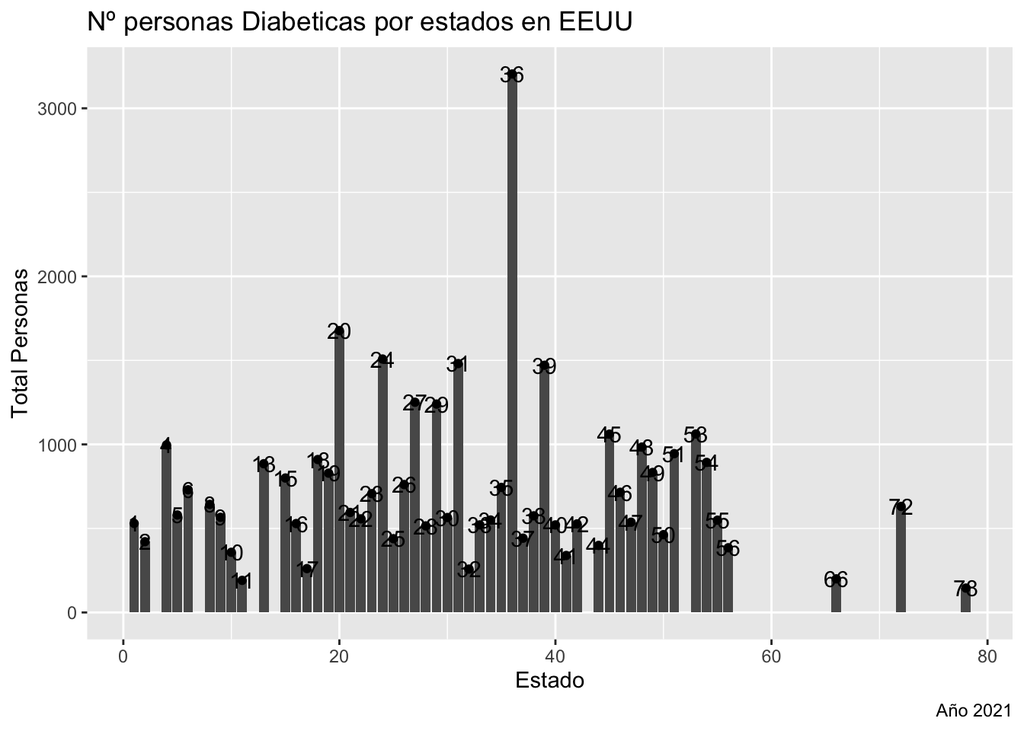

```r
diabeticos %>% group_by(State) %>%
          dplyr::summarise(total = n()) %>%
          ggplot(aes(x = State, y=total)) +
          geom_col(stat = "identity") +
          geom_point(bins = 30) +
        geom_text(aes(label=State)) +
          labs(title='Nº personas Diabeticas por estados en EEUU',
                   x='Estado',
                   y='Total Personas',
                   colour = "Cylinders",
                   caption = "Año 2021")
```

```r
# ggplot(data=diabeticos,aes(x=Diabetes_012,fill=diabeticos["State"]))+geom_bar()+ggtitle("Relación entre las variables conductor bebido y Estado")+labs(x="Número de conductores bebidos implicados")
```

A continuación, exploraremos las personas con diabetes y fumadoras, pero agrupados por género.

```r
diabeticofumadoresPorGenero <- diabeticos %>% filter(Smoker == 1) %>% group_by(Sex) %>%
  dplyr::summarize(total = n())

  diabeticofumadoresPorGenero
```

```
## # A tibble: 2 × 2
##     Sex total
##   <dbl> <int>
## 1     0  8079
## 2     1 10740
```

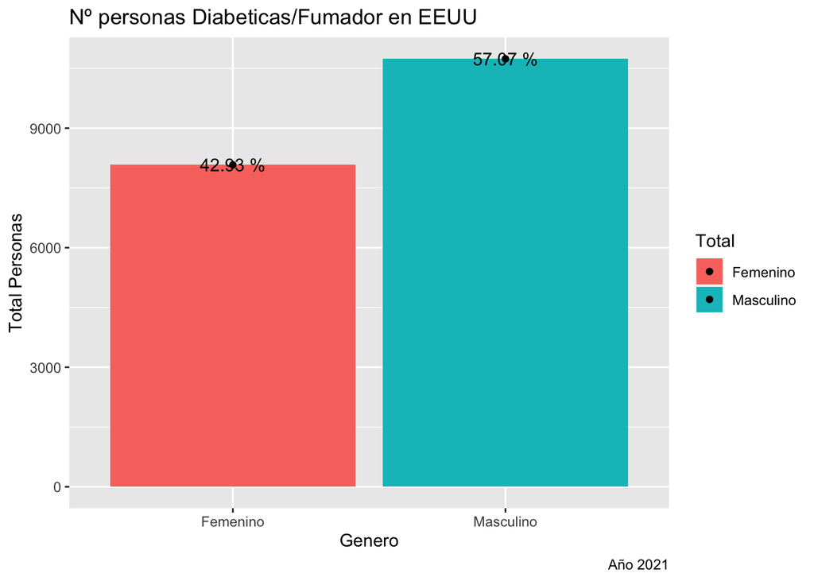

```r
  diabeticofumadoresPorGenero%>%
   ggplot(aes(x = c("Femenino", "Masculino"), y=total, fill=c("Femenino", "Masculino"))) +
    geom_col(stat = "identity") +
    guides(fill = guide_legend(title = "Total"), color=guide_legend(title="Genero"))+
    geom_text(aes(label=paste(round((total/sum(total)*100),2),"%"))) +
    geom_point(bins = 30) +
    labs(title='Nº personas Diabeticas/Fumador en EEUU',
             x='Genero',
             y='Total Personas',
             colour = "Cylinders",
             caption = "Año 2021")
```

Ahora bien, se puede observar que entre toda la población diabética de la muestra que fuma, el 57.07% corresponde al género Masculino.

No solo el fumar es uno de los factores que se ha encontrado que influye directamente en la aparición de la enfermedad o en la aceleración de esta, tenemos otros factores como el colesterol, peso, actividad física, consumo de alcohol, consumo de frutas, entre otros factores que serán analizados a continuación.

```r
library("gridExtra")
```

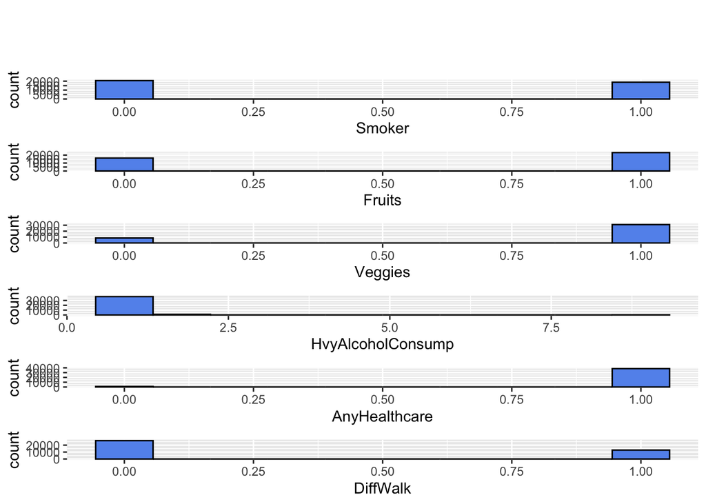

```
## [1] 0
```

```r
histList<- list()
n = c("Smoker","Fruits","Veggies","HvyAlcoholConsump","AnyHealthcare","DiffWalk")
diabeticosAux= diabeticos %>% select(all_of(n))

for(y in 1:ncol(diabeticosAux))
{
  col <- names(diabeticosAux)[y]
  ggp <- ggplot(diabeticosAux, aes_string(x = col)) +
  geom_histogram(bins = 10, fill = "cornflowerblue", color = "black")
  histList[[y]] <- ggp
}
multiplot(plotlist = histList, coles = 0)
```

Se puede apreciar que existen diferentes patologías o hábitos que influyen en la aparición o desarrollo de la enfermedad, además no es solo cuestión de si llevar una vida saludable o no, ya que esto depende también del nivel de educación y de los ingresos que percibe una persona, no es lo mismo una persona que percibe un sueldo mínimo, a este le cuesta un poco más poder adquirir alimentos de “calidad” y cubrir otros gastos de salud (revisiones periodicas, especialistas, etc), que una persona que tiene un sueldo mayor que le permite cubrir estas necesidades con mayor comodidad.

Realizaremos un previo analisis de si el nivel de educación alcanzado entre las personas encuestadas y de ingresos tiene influencia.

```r
diabeticoEducacion <- diabeticos %>% group_by(Education) %>%
  dplyr::summarize(total = n())

  diabeticoEducacion
```

```
## # A tibble: 6 × 2
##   Education total
##       <dbl> <int>
## 1         1    48
## 2         2   887
## 3         3  1841
## 4         4 10854
## 5         5 12203
## 6         6 13647
```

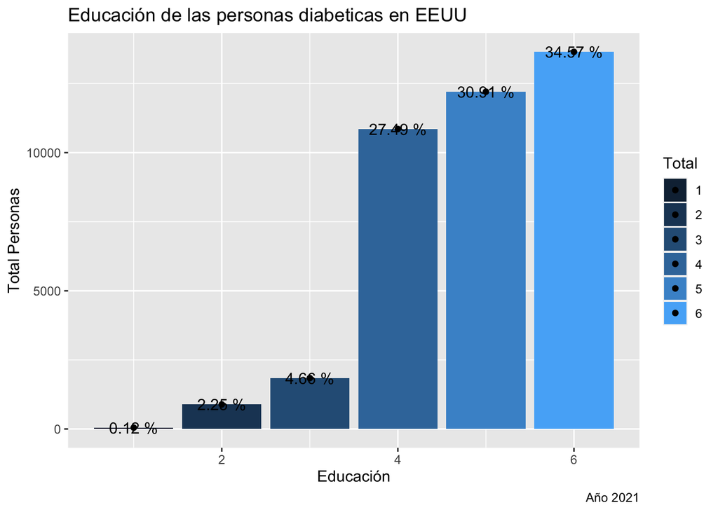

```r
  diabeticoEducacion%>%
   ggplot(aes(x = Education, y=total, fill=Education)) +
    geom_col(stat = "identity") +
    guides(fill = guide_legend(title = "Total"), color=guide_legend(title="Educación"))+
    geom_text(aes(label=paste(round((total/sum(total)*100),2),"%"))) +
    geom_point(bins = 30) +
    labs(title='Educación de las personas diabeticas en EEUU',
             x='Educación',
             y='Total Personas',
             colour = "Cylinders",
             caption = "Año 2021")
```

Ahora bien, una vez hemos analizado el nivel de educación de las personas que padecen de diabetes, podemos concluir que la falta o escasa educación no es un factor relevante, ya que vemos gran porcentaje de los diabéticos tienen una educación superior.

```r
  summary(diabeticos$Income)
```

```
##    Min. 1st Qu.  Median    Mean 3rd Qu.    Max.
##   1.000   5.000   6.000   6.065   8.000  11.000
```

```r
  diabeticoIngresos <- diabeticos %>% group_by(Income) %>%
  dplyr::summarize(total = n())

  diabeticoIngresos
```

```
## # A tibble: 11 × 2
##    Income total
##     <dbl> <int>
##  1      1  1660
##  2      2  2172
##  3      3  2379
##  4      4  3233
##  5      5  5983
##  6      6  6139
##  7      7  6749
##  8      8  4634
##  9      9  4062
## 10     10  1398
## 11     11  1071
```

[figure not shown]

```r
  diabeticoIngresos%>%
   ggplot(aes(x = Income, y=total, fill=Income)) +
    geom_col(stat = "identity") +
    guides(fill = guide_legend(title = "Total"), color=guide_legend(title="Educación"))+
    geom_text(aes(label=paste(round((total/sum(total)*100),2),"%"))) +
    geom_point(bins = 30) +
    labs(title='Educación de las personas diabeticas en EEUU',
             x='Educación',
             y='Total Personas',
             colour = "Cylinders",
             caption = "Año 2021")
```

Ahora bien, podemos apreciar que la mayoría de las personas que padecen de diabetes perciben unos ingresos mayor o igual a $35,000, pensaríamos que a menor ingreso mayor podría ser el impacto de este en la salud de las personas, pero el caso es que la falta o escasez de esto no es un factor que influye directamente y que también hay que tener en cuenta el otro conjunto de factores.

A continuación, vamos a analizar el índice de masa corporal de las personas que padecen de diabetes y de las personas que no lo padecen, ya que una persona con diabetes tiende a tener sobrepeso debido al consumo de alimentos altos en azucares y a la falta de actividad física.

```r
  summary(diabeticos$BMI)
```

```
##    Min. 1st Qu.  Median    Mean 3rd Qu.    Max.
##   12.00   27.00   31.00   32.08   36.00   99.00
```

```r
  diabeticoBMI <- diabeticos %>% group_by(BMI) %>%
  dplyr::summarize(total = n())

  diabeticoBMI
```

```
## # A tibble: 78 × 2
##      BMI total
##    <dbl> <int>
##  1    12     1
##  2    13     3
##  3    14     8
##  4    15    11
##  5    16    34
##  6    17    56
##  7    18    87
##  8    19   180
##  9    20   335
## 10    21   456
## # … with 68 more rows
```

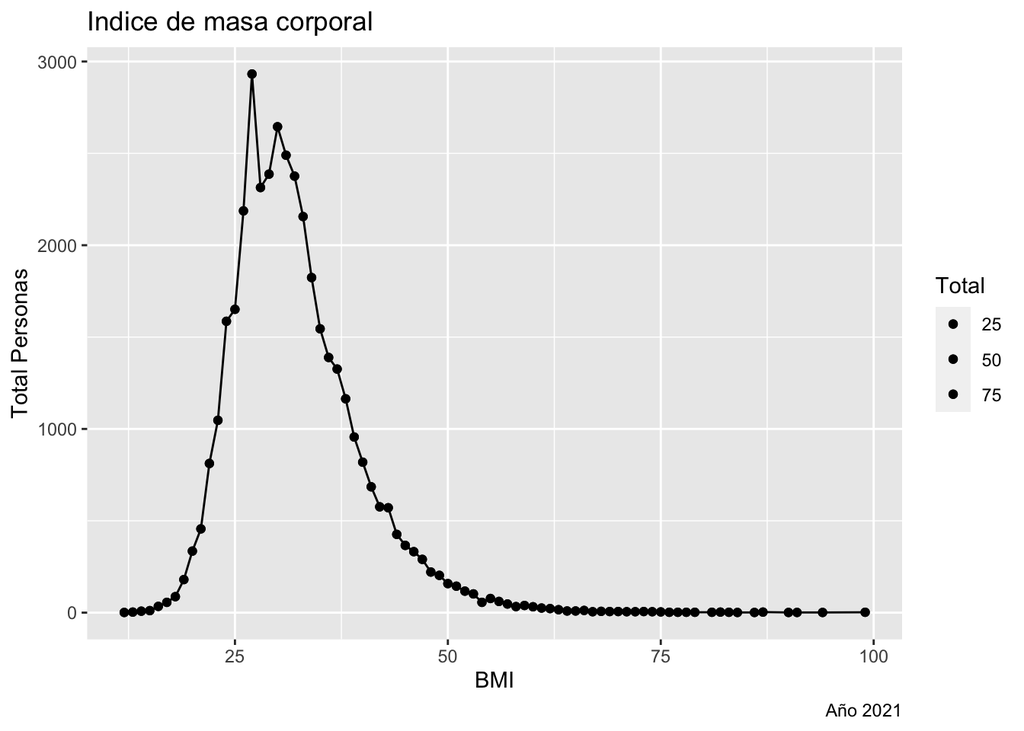

```r
    diabeticoBMI%>%
    ggplot(aes(x = BMI, y=total, fill=BMI)) +
    geom_point() +
    geom_line()+
    guides(fill = guide_legend(title = "Total"), color=guide_legend(title="BMI"))+
    geom_point(bins = 30) +
    labs(title='Indice de masa corporal',
             x='BMI',
             y='Total Personas',
             colour = "Cylinders",
             caption = "Año 2021")
```

Indice de masa corporal en personas No diabetica

```r
  nodiabeticos <- newDiabetesData %>% filter(Diabetes_012 == 0)
  summary(nodiabeticos$BMI)
```

```
##    Min. 1st Qu.  Median    Mean 3rd Qu.    Max.
##   12.00   24.00   27.00   28.33   31.00   98.00
```

```r
  nodiabeticoBMI <- nodiabeticos %>% group_by(BMI) %>%
  dplyr::summarize(total = n())

  diabeticoBMI
```

```
## # A tibble: 78 × 2
##      BMI total
##    <dbl> <int>
##  1    12     1
##  2    13     3
##  3    14     8
##  4    15    11
##  5    16    34
##  6    17    56
##  7    18    87
##  8    19   180
##  9    20   335
## 10    21   456
## # … with 68 more rows
```

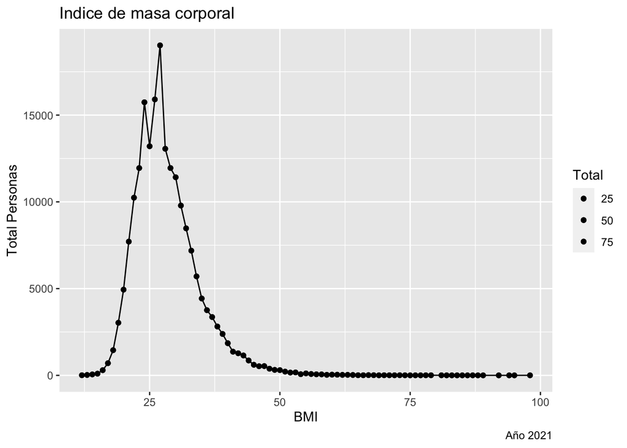

```r
    nodiabeticoBMI%>%
    ggplot(aes(x = BMI, y=total, fill=BMI)) +
    geom_point() +
    geom_line()+
    guides(fill = guide_legend(title = "Total"), color=guide_legend(title="BMI"))+
    geom_point(bins = 30) +
    labs(title='Indice de masa corporal',
             x='BMI',
             y='Total Personas',
             colour = "Cylinders",
             caption = "Año 2021")
```

Si nos basamos en este grafico del índice de masa corporal, podemos ver que gran parte de las personas diabéticas de este estudio, tienen sobrepeso u obesidad, es por ello ,por lo que podemos concluir que el peso es algo que está relacionado directamente en la suma de varios factores que aportan a la aparición de esta enfermedad, no estamos afirmando que, si una persona con sobre peso u obesidad debe tener diabetes, No, pero si es más propensa a que padezca de esta enfermedad.

Al igual que las personas con diabetes, podemos ver también que las personas sin diabetes padecen problemas de sobrepeso y obesidad, pero aun así no padecen de diabetes, ya que esta enfermedad no es solo condición del peso, sino que también son la suma de otros factores.

Ahora veremos la cantidad de personas que, según su índice de masa corporal según la tabla, están clasificadas en los siguientes grupos:

- Debajo de lo normal
- Normal
- Sobrepeso
- Obesidad

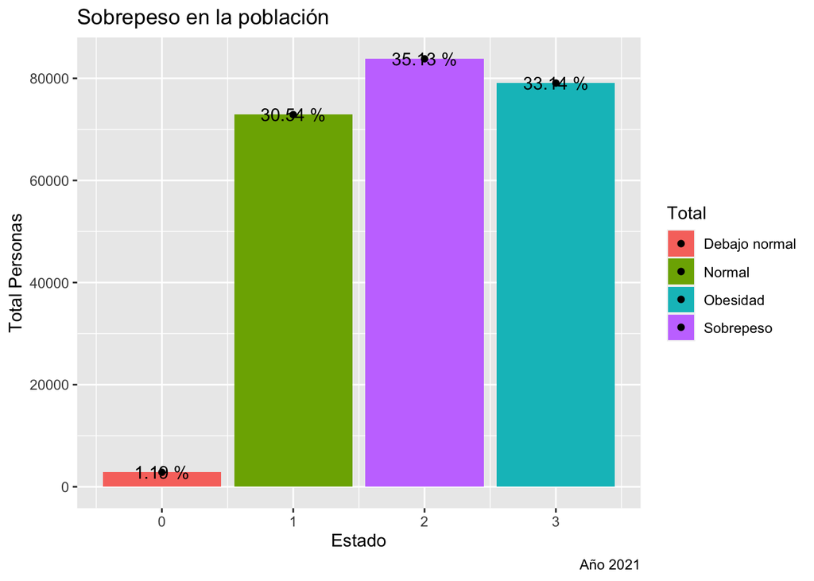

```r
newDiabetesData%>% group_by(BMIG) %>%
      dplyr::summarize(total = n()) %>%
      ggplot(aes(x = BMIG, y=total, fill=c("Debajo normal", "Normal", "Sobrepeso", "Obesidad"))) +
      geom_col(stat = "identity") +
      guides(fill = guide_legend(title = "Total"), color=guide_legend(title="Estado"))+
      geom_text(aes(label=paste(round((total/sum(total)*100),2),"%"))) +
      geom_point(bins = 30) +
      labs(title='Sobrepeso en la población',
               x='Estado',
               y='Total Personas',
               colour = "Cylinders",
               caption = "Año 2021")
```

Si vemos un poco más a detalle de la gráfica, podemos observar que existe un gran porcentaje de personas que tiene o sobrepeso u obesidad, para ser más detallados, el 68,27% de toda la población de estudio tiene este problema con su salud, ahora para ser un poco más detallados con la población diabética, realizaremos el mismo estudio pero con esta población.

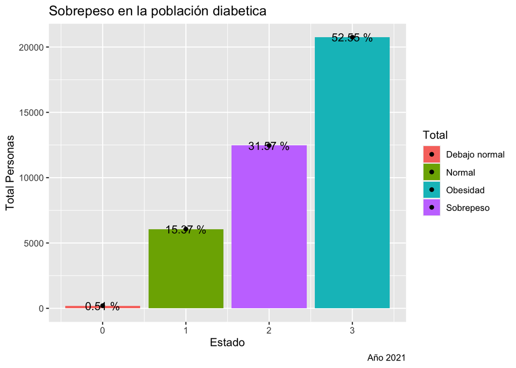

```r
#Diabeticos
diabeticos%>% group_by(BMIG) %>%
      dplyr::summarize(total = n()) %>%
      ggplot(aes(x = BMIG, y=total, fill=c("Debajo normal", "Normal", "Sobrepeso", "Obesidad"))) +
       geom_col(stat = "identity") +
      guides(fill = guide_legend(title = "Total"), color=guide_legend(title="Estado"))+
      geom_text(aes(label=paste(round((total/sum(total)*100),2),"%"))) +
      geom_point(bins = 30) +
      labs(title='Sobrepeso en la población diabetica',
               x='Estado',
               y='Total Personas',
               colour = "Cylinders",
               caption = "Año 2021")
```

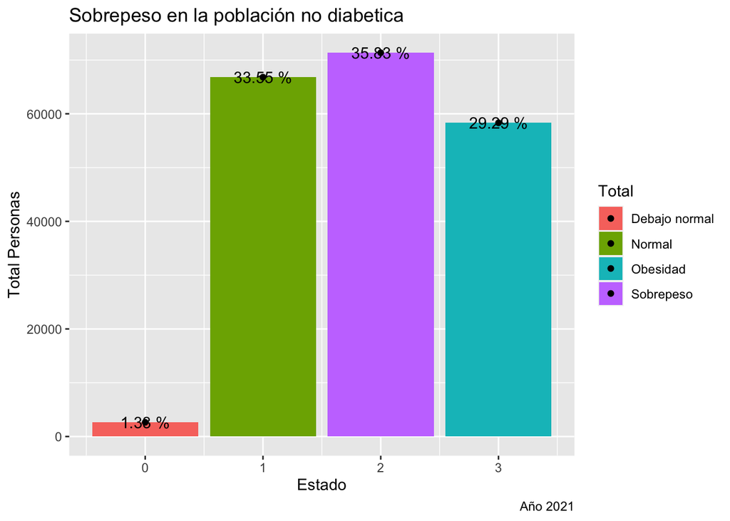

```r
#No diabeticos
nodiabeticos%>% group_by(BMIG) %>%
      dplyr::summarize(total = n()) %>%
      ggplot(aes(x = BMIG, y=total, fill=c("Debajo normal", "Normal", "Sobrepeso", "Obesidad"))) +
      geom_col(stat = "identity") +
      guides(fill = guide_legend(title = "Total"), color=guide_legend(title="Estado"))+
      geom_text(aes(label=paste(round((total/sum(total)*100),2),"%"))) +
      geom_point(bins = 30) +
      labs(title='Sobrepeso en la población no diabetica',
               x='Estado',
               y='Total Personas',
               colour = "Cylinders",
               caption = "Año 2021")
```

Muchas veces relacionamos el sobrepeso a otras enfermedades o dificultades que nos impiden realizar actividad física, entre ellos la dificultad de movilidad. A continuación, analizaremos si las personas que tienen sobrepeso u obesidad presentan algún problema de movilidad.

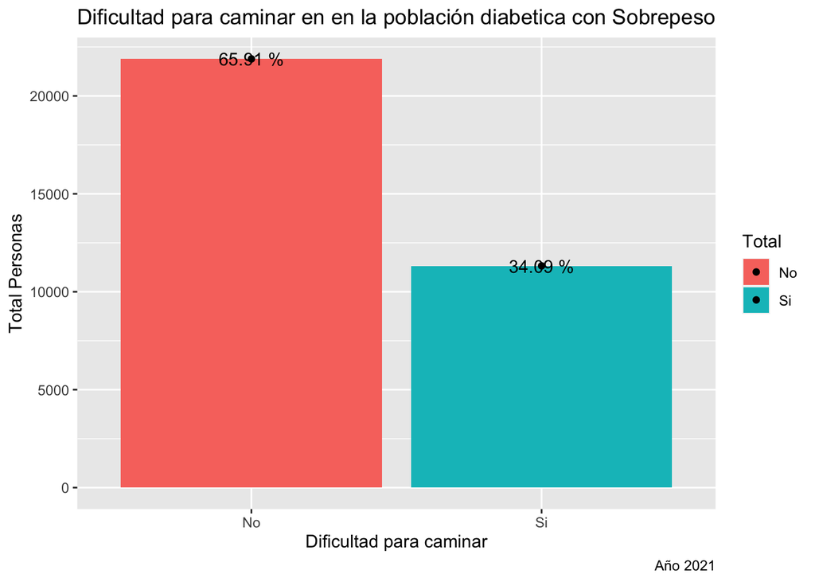

```r
#Diabeticos y movilidad
diabeticos%>% filter(BMIG %in% c(2,3)) %>%
      group_by(DiffWalk) %>%
      dplyr::summarize(total = n()) %>%
      ggplot(aes(x = c("No", "Si"), y=total, fill=c("No", "Si"))) +
       geom_col(stat = "identity") +
      guides(fill = guide_legend(title = "Total"), color=guide_legend(title="Estado"))+
      geom_text(aes(label=paste(round((total/sum(total)*100),2),"%"))) +
      geom_point(bins = 30) +
      labs(title='Dificultad para caminar en en la población diabetica con Sobrepeso',
               x='Dificultad para caminar',
               y='Total Personas',
               colour = "Cylinders",
               caption = "Año 2021")
```

Ahora bien, hasta este punto hemos analizado casi todas las variables (Factores) que hacen que una persona padezca de diabetes.

Para el siguiente analisis, necesitaremos categorizar la variable FRUITJU2 que hace referencia a si una persona consume jugos naturales sin azucares añadados, en base a la siguiente tabla se procede a realizar la categorización.

```
#FRUITJU2
# Not including fruit-flavored drinks or fruit juices with added sugar, how often did you drink 100% fruit juice such as apple or orange juice?
#Remove 777 and 999 for don't know and refused
#Replace 101 - 199 per 1 a diario
#Replace 201 - 299 per 2 semanal
#Replace 300 per 3 menos de una vez al mes
#Replace 301 - 399 -> 4 mensual / anual
#Replace 555 per 0 nunca
```

```r
sum(is.na(diabeticos["FRUITJU2"]))
```

```
## [1] 0
```

```r
summary(diabeticos$FRUITJU2)
```

```
##    Min. 1st Qu.  Median    Mean 3rd Qu.    Max.
##   101.0   203.0   314.0   381.2   555.0   555.0
```

```r
diabeticos = subset(diabeticos, diabeticos["FRUITJU2"] !=777)
diabeticos = subset(diabeticos, diabeticos["FRUITJU2"] !=999)

diabeticos["FRUITJU2"][diabeticos["FRUITJU2"]==555] <- 0
diabeticos["FRUITJU2"][diabeticos["FRUITJU2"]>=101 & diabeticos["FRUITJU2"]<=199] <- 1
diabeticos["FRUITJU2"][diabeticos["FRUITJU2"]>=201 & diabeticos["FRUITJU2"]<=299] <- 2
diabeticos["FRUITJU2"][diabeticos["FRUITJU2"]==300] <- 3
diabeticos["FRUITJU2"][diabeticos["FRUITJU2"]>=301 & diabeticos["FRUITJU2"]<=399] <- 4
```

La aparición o desarrollo de esta enfermedad se la relaciona muchas veces con el consumo excesivo de azucares, no solo en las frutas y vegetales, sino que está presente muchas veces en alimentos que son catalogados como “dañinos para la salud” por expertos en la salud, estos alimentos suelen ser ultra procesados y bebidas con alto porcentaje de azucares añadidos, como los zumos embotellados artificiales y gaseosas.

La recomendación de los expertos de la salud es que estas bebidas sean reemplazadas por zumos naturales o directamente se elimine su consumo, es por ello que en esta encuesta se pregunta a las personas sobre la frecuencia con la que consumen bebidas naturales y las respuestas obtenidas serán analizadas a continuación y así poder sacar una conclusión, si en realidad esto puede ser o no un factor en la enfermedad.

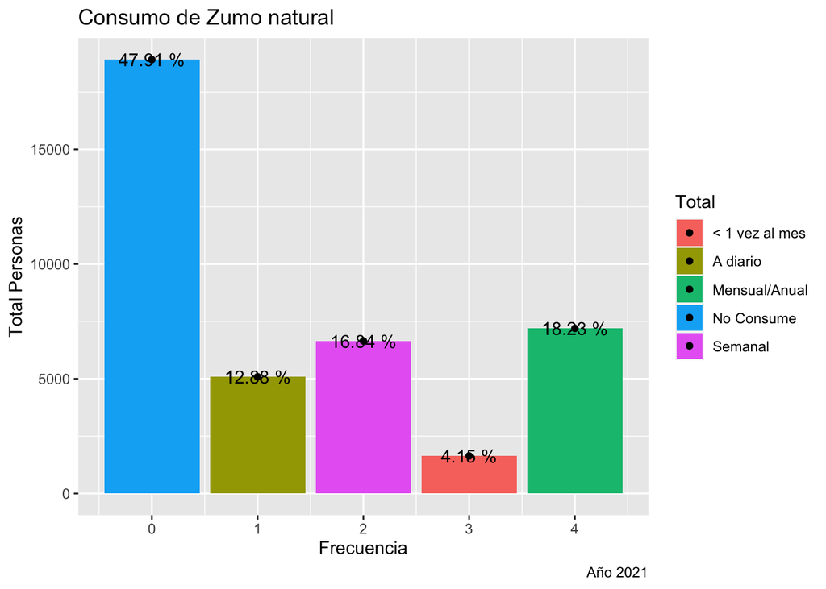

```r
  FRUITJU2Summary <- c("No Consume", "A diario", "Semanal", "< 1 vez al mes", "Mensual/Anual")
   diabeticos %>% group_by(FRUITJU2) %>%
    dplyr::summarize(total = n()) %>%
      ggplot(aes(x = FRUITJU2, y=total, fill=FRUITJU2Summary)) +
      geom_col(stat = "identity") +
      #theme(axis.text.x = element_text(angle = 90, size=4)) +
      guides(fill = guide_legend(title = "Total"), color=guide_legend(title="Educación"))+
      geom_text(aes(label=paste(round((total/sum(total)*100),2),"%"))) +
      geom_point(bins = 30) +
      labs(title='Consumo de Zumo natural',
               x='Frecuencia',
               y='Total Personas',
               colour = "Cylinders",
               caption = "Año 2021")
```

Podemos observar que cerca del 48% de las personas con diabetes no consumen zumos naturales sin azucares añadidos, se estima que de las personas que padecen de esta enfermedad consumen bebidas artificiales que tienen alto contenido en azucares, tales como las gaseosas, zumos, entre otras bebidas más.

A continuación, analizaremos otros factores en las personas con diabetes, factores que hacen que el control de la enfermedad sea más llevadero, como la frecuencia con la que se controla la glucosa, pruebas médicas periódicas para conocer la evolución de la enfermedad y frecuencia con la que un médico le realiza el control de la enfermedad.

```
#BLDSUGAR Con qué frecuencia se controla la glucosa o el azúcar en sangre
#replace 101 - 199 per 1 - una vez por dia
#replace 201 - 299 per 2 - una vez por semana
#replace 301 - 399 per 3 - una vez al mes
#replace 401 - 499 per 4 - una vez al año
#replace 888 per 0 - nunca
#removed 999, 777, BLANK
```

```r
sum(is.na(diabeticos["BLDSUGAR"]))
```

```
## [1] 26341
```

```r
diabeticos["BLDSUGAR"][is.na(diabeticos["BLDSUGAR"])] <- 0
diabeticos["BLDSUGAR"][diabeticos["BLDSUGAR"] >= 101 & diabeticos["BLDSUGAR"] <=199] <- 1
diabeticos["BLDSUGAR"][diabeticos["BLDSUGAR"] >= 201 & diabeticos["BLDSUGAR"] <=299] <- 2
diabeticos["BLDSUGAR"][diabeticos["BLDSUGAR"] >= 301 & diabeticos["BLDSUGAR"] <=399] <- 3
diabeticos["BLDSUGAR"][diabeticos["BLDSUGAR"] >= 401 & diabeticos["BLDSUGAR"] <=499] <- 4
diabeticos["BLDSUGAR"][diabeticos["BLDSUGAR"] == 888] <- 0
diabeticos = subset(diabeticos, diabeticos["BLDSUGAR"] !=999)
diabeticos = subset(diabeticos, diabeticos["BLDSUGAR"] !=777)
```

```r
summary(diabeticos$BLDSUGAR)
```

```
##    Min. 1st Qu.  Median    Mean 3rd Qu.    Max.
##  0.0000  0.0000  0.0000  0.4561  1.0000  4.0000
```

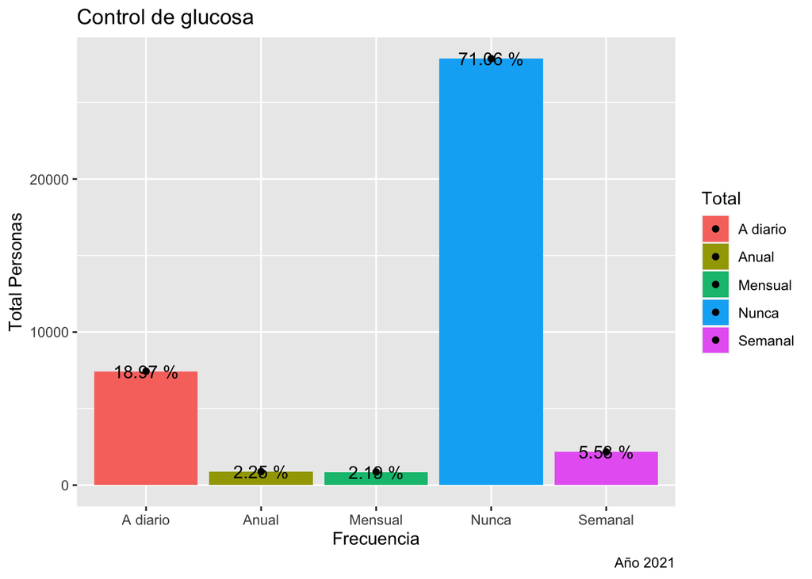

```r
 BLDSUGARSummary <- c("Nunca", "A diario", "Semanal", "Mensual", "Anual")
   diabeticos %>% group_by(BLDSUGAR) %>%
    dplyr::summarize(total = n()) %>%
      ggplot(aes(x = BLDSUGARSummary, y=total, fill=BLDSUGARSummary)) +
      geom_col(stat = "identity") +
      #theme(axis.text.x = element_text(angle = 90, size=4)) +
      guides(fill = guide_legend(title = "Total"), color=guide_legend(title="Educación"))+
      geom_text(aes(label=paste(round((total/sum(total)*100),2),"%"))) +
      geom_point(bins = 30) +
      labs(title='Control de glucosa',
               x='Frecuencia',
               y='Total Personas',
               colour = "Cylinders",
               caption = "Año 2021")
```

Vemos que el control de la glucosa no es algo muy habitual en las personas que padecen de diabetes, es por ello que muchos dejan que la enfermedad avance hasta tal punto que trae complicación para su salud, complicaciones como amputación de extremidades, pérdida de visión, etc.

```
#DOCTDIAB Visita medica por su diabetes en los ultimos 12 meses
#replace 1 - 76 Number of times, 76=76 or more
#replace 1 - 20 per 1 -> de una a 20 veces
#replace 21 - 40 per 2 -> de 21 a 40 veces
#replace 41 - 60 per 3 -> de 41 a 60 veces
#replace 61 > n  per 4 -> igual o mas de 61 veces

#replace 88  - 0 ninguno
#remove 77, 99,BLANK
```

```r
sum(is.na(diabeticos["DOCTDIAB"]))
```

```
## [1] 26345
```

```r
diabeticos = subset(diabeticos, !is.na(diabeticos["DOCTDIAB"]))
diabeticos["DOCTDIAB"][diabeticos["DOCTDIAB"] == 88] <- 0
diabeticos = subset(diabeticos, diabeticos["DOCTDIAB"] !=77)
diabeticos = subset(diabeticos, diabeticos["DOCTDIAB"] !=99)
diabeticos["DOCTDIAB"][diabeticos["DOCTDIAB"] >= 1 & diabeticos["DOCTDIAB"] <=20] <- 1
diabeticos["DOCTDIAB"][diabeticos["DOCTDIAB"] >= 21 & diabeticos["DOCTDIAB"] <=40] <- 2
diabeticos["DOCTDIAB"][diabeticos["DOCTDIAB"] >= 41 & diabeticos["DOCTDIAB"] <=60] <- 3
diabeticos["DOCTDIAB"][diabeticos["DOCTDIAB"] > 60] <- 4


summary(diabeticos$DOCTDIAB)
```

```
##    Min. 1st Qu.  Median    Mean 3rd Qu.    Max.
##  0.0000  1.0000  1.0000  0.9129  1.0000  4.0000
```

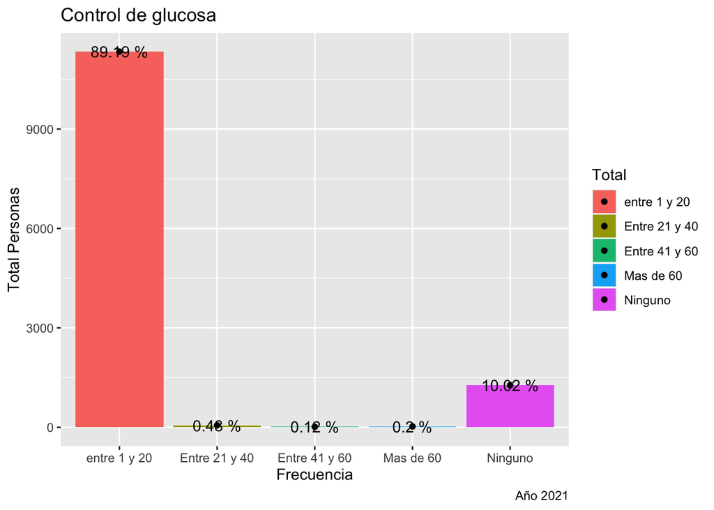

```r
DOCTDIABummary <- c("Ninguno", "entre 1 y 20", "Entre 21 y 40", "Entre 41 y 60", "Mas de 60")
   diabeticos %>% group_by(DOCTDIAB) %>%
    dplyr::summarize(total = n()) %>%
      ggplot(aes(x = DOCTDIABummary, y=total, fill=DOCTDIABummary)) +
      geom_col(stat = "identity") +
      #theme(axis.text.x = element_text(angle = 90, size=4)) +
      guides(fill = guide_legend(title = "Total"), color=guide_legend(title="Educación"))+
      geom_text(aes(label=paste(round((total/sum(total)*100),2),"%"))) +
      geom_point(bins = 30) +
      labs(title='Control de glucosa',
               x='Frecuencia',
               y='Total Personas',
               colour = "Cylinders",
               caption = "Año 2021")
```

Se puede observar, que las personas enfermas de diabetes tienen habito de visitar al profesional médico para llevar un control de la enfermedad al menos 1 vez al año, aunque existe también un porcentaje considerable (10%) que no se plantea en llevar un control médico.

Ahora bien, una vez en este punto, graficaremos una matriz de correlación que nos permitira ver cuales son las variables que estan debil y fuertemente correlacionadas entre ellas, en base a esta matriz concluiremos:

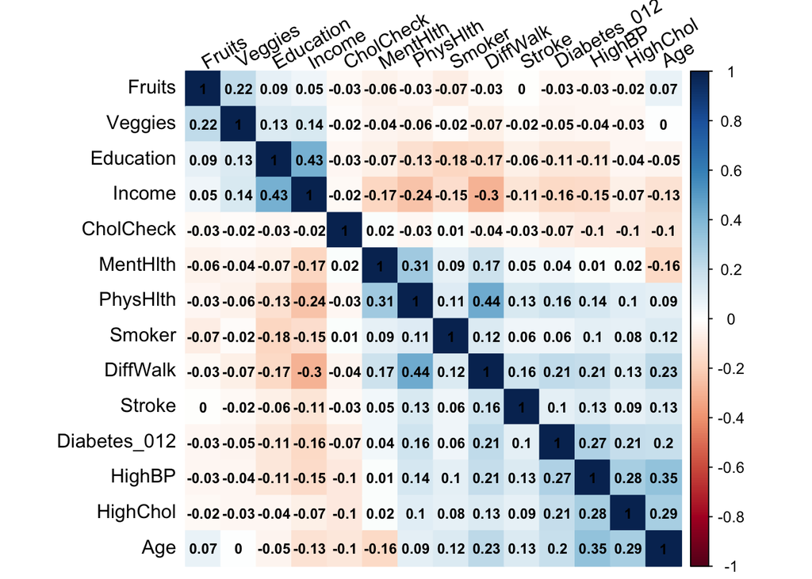

```r
if(!require("corrplot")) install.packages("corrplot"); library("corrplot")
n = c("Diabetes_012","HighBP","HighChol","Smoker","CholCheck","Stroke","Fruits","Veggies","DiffWalk","Education","Income","Age","PhysHlth","MentHlth")

factores= newDiabetesData %>% select(all_of(n))
res<-cor(factores)
corrplot(res,method="color",tl.col="black", tl.srt=30, order = "AOE",
number.cex=0.75,sig.level = 0.01, addCoef.col = "black")
```

## Proceso de análisis de componentes principale s - PCA

A continuación aplicaremos tecnicas de analisis que nos permitan trabajar con nuevas características llamadas componentes, que son independientes entre sí.

Esta tecnica nos permite representar el juego de datos en un nuevo sistema de coordenadas que denominamos componentes principales. Esta tecnica nos permite recoger la mejor variabilidad de los datos.

Para no extender el analisis de todas las variables, proponemos seleccionar las caracteristicas que consideramos mas relevantes en este analisis, las cuales seran separadas y guardadas dentro de un nuevo dataset.

```r
diabeticosAuxPCA = newDiabetesData %>% select(all_of(c("Diabetes_012","Smoker","Fruits","Veggies","HvyAlcoholConsump","AnyHealthcare","DiffWalk")))
```

El primer paso sera la utilización de la función prcomp (Principal component), esta función requiere el dataset que se desea analizar, para este ejemplo escalaremos los valores.

```r
respca<- prcomp(diabeticosAuxPCA, scale=TRUE)
names(respca)
```

```
## [1] "sdev"     "rotation" "center"   "scale"    "x"
```

Se puede apreciar que ahora contamos con una nueva variable, donde tendremos disponible la desviación tipica, la rotación, los centroides, las escales que seran graficadas mas adelante.

Ahora bien, obtendremos la rotación y analizaremos un poco el resultado.

```r
head(respca$rotation)[,1:6] # Coordenadas de los datos en el nuevo sistema
```

```
##                           PC1        PC2        PC3          PC4        PC5
## Diabetes_012       0.46464852 -0.4290778  0.1262409 -0.092607622  0.3758942
## Smoker             0.36729107 -0.1001301 -0.5284547 -0.008419977 -0.6959775
## Fruits            -0.42696152 -0.5302576 -0.1258397 -0.179461063  0.1538147
## Veggies           -0.43982097 -0.4880177 -0.2718040 -0.052071770 -0.1614781
## HvyAlcoholConsump  0.01481832  0.1539928 -0.7051989  0.461391832  0.5156058
## AnyHealthcare     -0.02879869 -0.3028405  0.3415404  0.859610756 -0.2113613
##                            PC6
## Diabetes_012      -0.562700125
## Smoker            -0.018645561
## Fruits             0.461571180
## Veggies           -0.459031730
## HvyAlcoholConsump  0.005396944
## AnyHealthcare      0.044966766
```

Se puede apreciar que por cada coordenada, la rotación de cada componente para cada una de las variables disponibles del dataset, a breves rasgos podemos ver que variable tiene mayor peso en cada uno de los componentes.

```r
head(respca$center)# Coordenadas de los datos en el nuevo sistema
```

```
##      Diabetes_012            Smoker            Fruits           Veggies
##         0.1654576         0.4127806         0.6210904         0.8276483
## HvyAlcoholConsump     AnyHealthcare
##         1.1363684         0.9623446
```

```r
head(respca$sdev)# Coordenadas de los datos en el nuevo sistema
```

```
## [1] 1.1643485 1.0736536 1.0217989 0.9903944 0.9586296 0.8915794
```

```r
head(respca$x)# Coordenadas de los datos en el nuevo sistema
```

```
##              PC1        PC2        PC3         PC4        PC5         PC6
## [1,] -0.53383004 -0.4749368 -0.7068975 -0.01224218 -1.1311781  0.17103007
## [2,]  1.13508506 -0.1341313  1.4258494 -0.10648708  1.7215658 -0.09000912
## [3,] -0.02942802 -1.4262548  0.7061945 -0.24435740  1.2940205 -1.30538649
## [4,]  1.41692085 -2.5725395  0.6130196 -0.43275734  1.6226305  0.10003224
## [5,]  2.95715337  0.7639539  0.1789833  0.30716209 -0.6920903  1.84036174
## [6,]  0.91251883 -1.6212215 -0.8000724 -0.20064211 -0.8025681  1.57644880
##             PC7
## [1,] -0.6082401
## [2,] -2.2552653
## [3,] -0.9181857
## [4,]  0.5467473
## [5,]  0.5539599
## [6,]  0.8566928
```

```r
print("Componentes")
```

```
## [1] "Componentes"
```

```r
dim(respca$rotation) #Numero de distintos componentes
```

```
## [1] 7 7
```

```r
print("Desviaciones estandar de cada componente")
```

```
## [1] "Desviaciones estandar de cada componente"
```

```r
respca$sdev #las desviaciones estandares de cada componente.
```

```
## [1] 1.1643485 1.0736536 1.0217989 0.9903944 0.9586296 0.8915794 0.8675954
```

```r
print("varianza explicada por cada componente")
```

```
## [1] "varianza explicada por cada componente"
```

```r
respca$sdev^2 #varianza explicada por componente
```

```
## [1] 1.3557075 1.1527321 1.0440729 0.9808811 0.9189707 0.7949138 0.7527218
```

Ahora bien, añadiremos el resultado obtenido de cada componente al dataset que fue previamente adaptado para este analisis, de esta forma podremos tener el resultado de cada componente, en cada fila con los datos originales.

```r
summary(respca)
```

```
## Importance of components:
##                           PC1    PC2    PC3    PC4    PC5    PC6    PC7
## Standard deviation     1.1643 1.0737 1.0218 0.9904 0.9586 0.8916 0.8676
## Proportion of Variance 0.1937 0.1647 0.1492 0.1401 0.1313 0.1136 0.1075
## Cumulative Proportion  0.1937 0.3584 0.5075 0.6476 0.7789 0.8925 1.0000
```

```r
#Comprobaremos la importancia del componente 1
xx<- respca$x
xx<-as.data.frame(xx)
diabeticosAuxPCA$PC1 <- xx$PC1
diabeticosAuxPCA$PC2 <- xx$PC2
diabeticosAuxPCA$PC3 <- xx$PC3
diabeticosAuxPCA$PC4 <- xx$PC4
diabeticosAuxPCA$PC5 <- xx$PC5
diabeticosAuxPCA$PC6 <- xx$PC6
head(diabeticosAuxPCA)
```

```
## # A tibble: 6 × 13
##   Diabetes…¹ Smoker Fruits Veggies HvyAl…² AnyHe…³ DiffW…⁴     PC1    PC2    PC3
##        <dbl>  <dbl>  <dbl>   <dbl>   <dbl>   <dbl>   <dbl>   <dbl>  <dbl>  <dbl>
## 1          0      1      1       1       1       1       0 -0.534  -0.475 -0.707
## 2          1      0      1       0       1       1       0  1.14   -0.134  1.43
## 3          1      0      1       1       1       1       0 -0.0294 -1.43   0.706
## 4          1      0      1       1       1       1       1  1.42   -2.57   0.613
## 5          0      1      0       0       1       1       1  2.96    0.764  0.179
## 6          0      1      1       1       1       1       1  0.913  -1.62  -0.800
## # … with 3 more variables: PC4 <dbl>, PC5 <dbl>, PC6 <dbl>, and abbreviated
## #   variable names ¹Diabetes_012, ²HvyAlcoholConsump, ³AnyHealthcare, ⁴DiffWalk
```

```r
#
# summary(dieabeticos_filtered$State)
```

Bien, ahora procedemos a imprimir una matriz de correlación y verificar la correlación entre el resultado de los componentes que fueron previamente obtenidos.

```r
cor(diabeticosAuxPCA)
```

```
##                   Diabetes_012       Smoker      Fruits      Veggies
## Diabetes_012        1.00000000  0.057782941 -0.03079623 -0.047556104
## Smoker              0.05778294  1.000000000 -0.07176183 -0.016867501
## Fruits             -0.03079623 -0.071761833  1.00000000  0.215774080
## Veggies            -0.04755610 -0.016867501  0.21577408  1.000000000
## HvyAlcoholConsump  -0.02587219  0.045141462 -0.01622520  0.002425924
## AnyHealthcare       0.02403255 -0.024065054  0.01940075  0.034299478
## DiffWalk            0.21279908  0.123348333 -0.02970781 -0.067205142
## PC1                 0.54101283  0.427654825 -0.49713202 -0.512104905
## PC2                -0.46068097 -0.107505002 -0.56931300 -0.523962008
## PC3                 0.12899276 -0.539974390 -0.12858282 -0.277729019
## PC4                -0.09171807 -0.008339098 -0.17773723 -0.051571591
## PC5                 0.36034330 -0.667184645  0.14745135 -0.154797716
## PC6                -0.50169184 -0.016623998  0.41152735 -0.409263231
##                   HvyAlcoholConsump AnyHealthcare    DiffWalk           PC1
## Diabetes_012           -0.025872187    0.02403255  0.21279908  5.410128e-01
## Smoker                  0.045141462   -0.02406505  0.12334833  4.276548e-01
## Fruits                 -0.016225196    0.01940075 -0.02970781 -4.971320e-01
## Veggies                 0.002425924    0.03429948 -0.06720514 -5.121049e-01
## HvyAlcoholConsump       1.000000000   -0.01670045 -0.01078517  1.725369e-02
## AnyHealthcare          -0.016700451    1.00000000  0.02116136 -3.353171e-02
## DiffWalk               -0.010785167    0.02116136  1.00000000  6.077090e-01
## PC1                     0.017253689   -0.03353171  0.60770902  1.000000e+00
## PC2                     0.165334965   -0.32514580 -0.44411587  4.832442e-13
## PC3                    -0.720571477    0.34898557 -0.03435611 -5.452336e-13
## PC4                     0.456959894    0.85135369 -0.06733309  2.122915e-13
## PC5                     0.494274953   -0.20261723  0.11367666 -1.055281e-12
## PC6                     0.004811804    0.04009144  0.45217378 -4.736217e-14
##                             PC2           PC3           PC4           PC5
## Diabetes_012      -4.606810e-01  1.289928e-01 -9.171807e-02  3.603433e-01
## Smoker            -1.075050e-01 -5.399744e-01 -8.339098e-03 -6.671846e-01
## Fruits            -5.693130e-01 -1.285828e-01 -1.777372e-01  1.474513e-01
## Veggies           -5.239620e-01 -2.777290e-01 -5.157159e-02 -1.547977e-01
## HvyAlcoholConsump  1.653350e-01 -7.205715e-01  4.569599e-01  4.942750e-01
## AnyHealthcare     -3.251458e-01  3.489856e-01  8.513537e-01 -2.026172e-01
## DiffWalk          -4.441159e-01 -3.435611e-02 -6.733309e-02  1.136767e-01
## PC1                4.832442e-13 -5.452336e-13  2.122915e-13 -1.055281e-12
## PC2                1.000000e+00 -2.420941e-14 -4.662766e-13  4.986354e-13
## PC3               -2.420941e-14  1.000000e+00  4.956668e-13  8.469216e-14
## PC4               -4.662766e-13  4.956668e-13  1.000000e+00 -1.542703e-13
## PC5                4.986354e-13  8.469216e-14 -1.542703e-13  1.000000e+00
## PC6               -1.474516e-12  3.390199e-14 -3.144709e-13  7.729157e-13
##                             PC6
## Diabetes_012      -5.016918e-01
## Smoker            -1.662400e-02
## Fruits             4.115274e-01
## Veggies           -4.092632e-01
## HvyAlcoholConsump  4.811804e-03
## AnyHealthcare      4.009144e-02
## DiffWalk           4.521738e-01
## PC1               -4.736217e-14
## PC2               -1.474516e-12
## PC3                3.390199e-14
## PC4               -3.144709e-13
## PC5                7.729157e-13
## PC6                1.000000e+00
```

A continuación hacemos uso de la función de PCA, esta es un poco mas sostisficada, ya que nos dara mas resultados, e incluso los valores perdidos, que podran ser reemplazados utilizando algun metodo que permita la imputación de estos valores.

Los parametros que se le pasan a la función son:

- Los datos
- Ningun tipo de escalado
- Numero de componentes
- Y ademas le pediremos que nos muestre todo esto en un grafico, donde podemos ver como se comportan cada una de las variables en un plano bidimensional.

```r
if (!require('FactoMineR')) install.packages('FactoMineR'); library('FactoMineR');
```

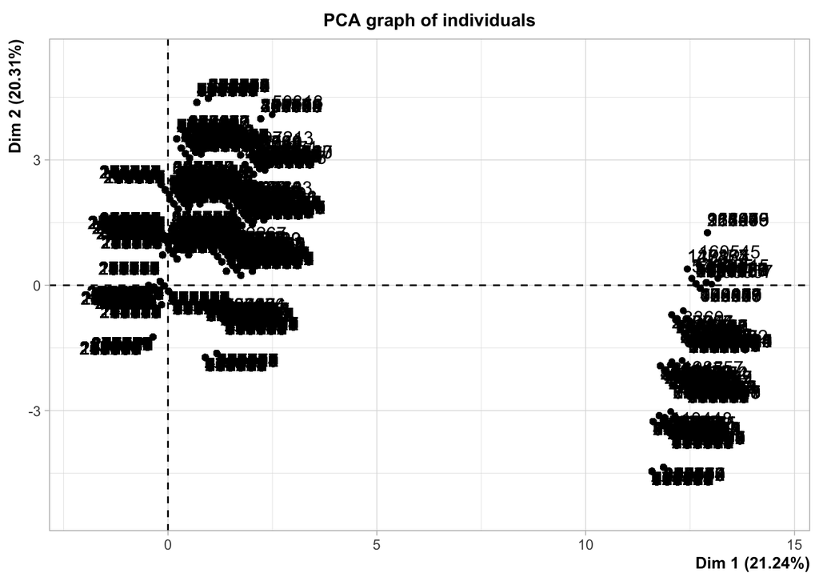

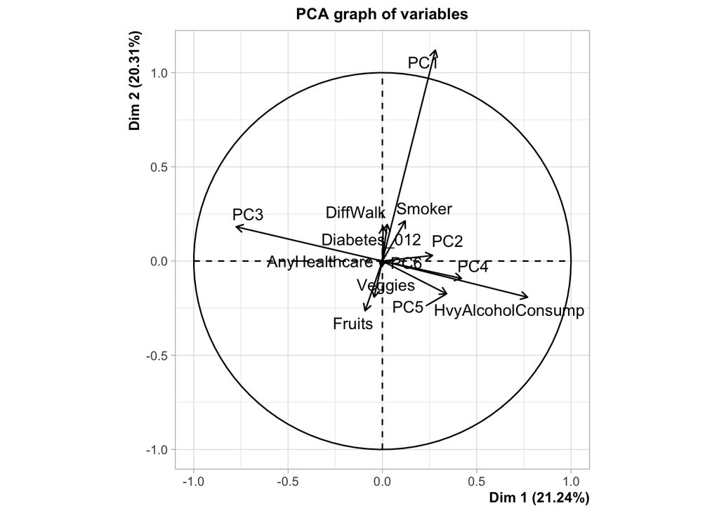

```r
respca2 <- PCA(X=diabeticosAuxPCA, scale.unit=FALSE, ncp = 6, graph=TRUE)
```

```r
# print(respca2)
# head(respca)
```

```r
if (!require('factoextra')) install.packages('factoextra'); library('factoextra');
get_pca(respca2)
```

```
## Principal Component Analysis Results for variables
##  ===================================================
##   Name       Description
## 1 "$coord"   "Coordinates for the variables"
## 2 "$cor"     "Correlations between variables and dimensions"
## 3 "$cos2"    "Cos2 for the variables"
## 4 "$contrib" "contributions of the variables"
```

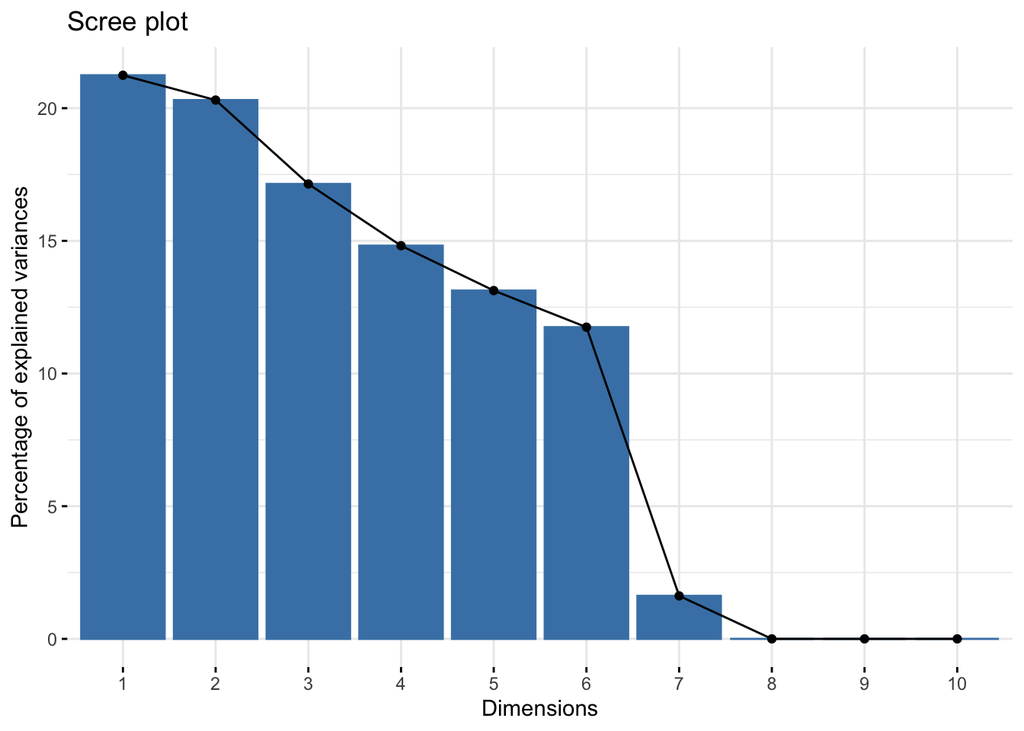

```r
#Visualizaciones
fviz_eig(respca2)
```

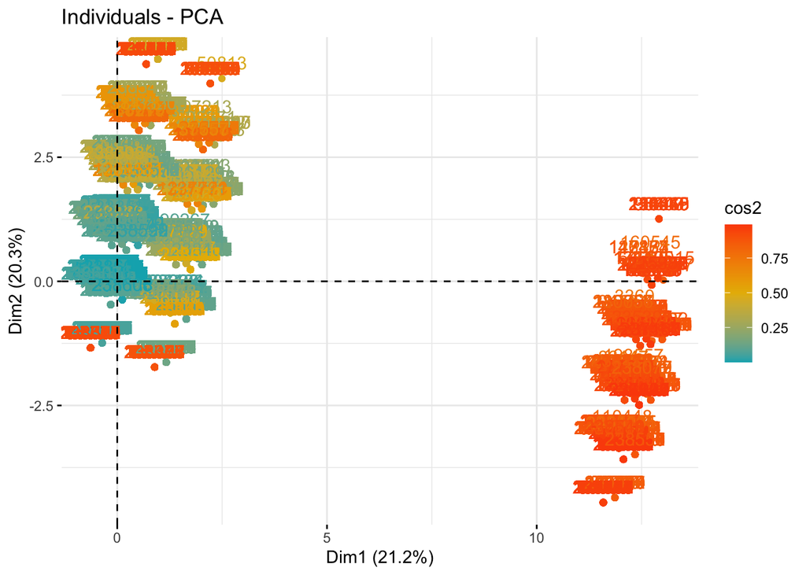

```r
fviz_pca_ind(respca2, col.ind = "cos2", gradient.cols=c("#00AFBB", "#E7B800", "#FC4E07"),
             repel=FALSE)
```

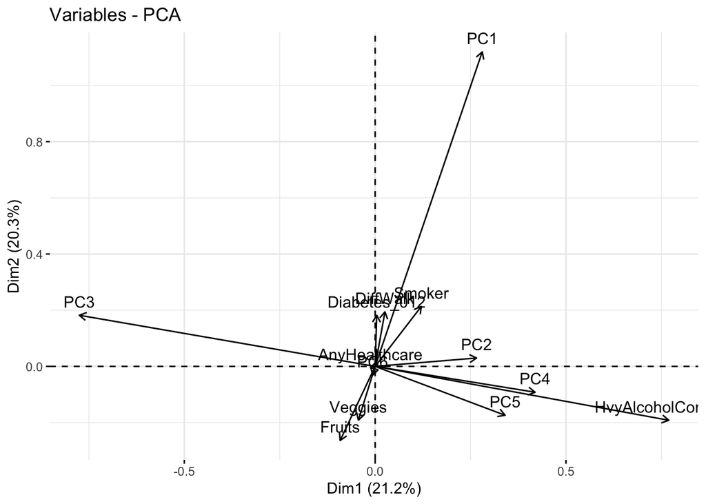

```r
fviz_pca_var(respca2)
```